# ANOVA Bifatorial

José O Siqueira (siqueira@usp.br) Paulo SP Silveira (silveira@usp.br)

23 julho 2024 17:36h

```r
invisible(Sys.setlocale("LC_CTYPE", "pt_BR.UTF-8"))
invisible(Sys.setlocale("LC_ALL", "pt_BR.UTF-8"))
```

```r
options(warn=-1)
suppressMessages(library(car, warn.conflicts=FALSE))
suppressMessages(library(emmeans, warn.conflicts=FALSE))
suppressMessages(library(gplots, warn.conflicts=FALSE))
suppressMessages(library(lmerTest, warn.conflicts=FALSE))
suppressMessages(library(multcomp, warn.conflicts=FALSE))
suppressMessages(library(MuMIn, warn.conflicts=FALSE))
suppressMessages(library(phia, warn.conflicts=FALSE))
suppressMessages(library(psych, warn.conflicts=FALSE))
suppressMessages(library(pwr2, warn.conflicts=FALSE))
suppressMessages(library(RcmdrMisc, warn.conflicts=FALSE))
suppressMessages(library(readxl, warn.conflicts=FALSE))
suppressMessages(library(twowaytests, warn.conflicts=FALSE))
suppressMessages(library(estimatr, warn.conflicts=FALSE))
suppressMessages(library(effectsize, warn.conflicts=FALSE))
suppressMessages(library(WebPower, warn.conflicts=FALSE))
suppressMessages(library(bruceR, warn.conflicts=FALSE))
source("summarySEwithin2.R")
```

# Material

- HTML de R Markdown em [`RPubs`](http://rpubs.com/josiqueira/)
- Arquivos em [`GitHub`](https://github.com/josiqueira/EstatMedR)

# Objetivos

- Discorrer sobre uma extensão da ANOVA que inclui dois ou mais fatores.
- Descrever e indicar três delineamentos diferentes da ANOVA com dois fatores:
  - independente: entre participantes,
  - relacionada: intraparticipantes,
  - mista: um fator entre e outro fator intraparticipantes.
- Proceder com a análise descritiva numérica e gráfica dos dados.
- Formular e implementar os modelos de ANOVA adequados a cada situação.
- Determinar as significâncias estatística e prática dos efeitos de interação e principais da ANOVA.
- Executar uma análise de efeito simples.
- Executar e interpretar os testes *post hoc*, quando adequados.

# Introdução

- [Two-way analysis of variance: Wikipedia](https://en.wikipedia.org/wiki/Two-way_analysis_of_variance)
- [Analysis of variance: Wikipedia](https://en.wikipedia.org/wiki/Analysis_of_variance)

ANOVA bifatorial permite testar efeitos principais e de interação numa única análise.

As variáveis envolvidas no teste estatístico são:

- duas ou mais VI (variável independente) com duas ou mais categorias (fatores nominais dicotômicos ou politômicos): multifatorial
- VD (variável dependente) intervalar com distribuição normal por condição: univariada

ANOVA multifatorial pode ser:

- independente (fator entre participantes)
- relacionada (fator intraparticipantes)
- mista (fatores entre e intraparticipantes)

ANOVA multifatorial é uma extensão do ANOVA unifatorial.

As suposições de normalidade homocedasticidade são condições suficientes e a suposição de independência é necessária para ANOVA multifatorial.

# ANOVA multifatorial em R

0. Planejamento de ANOVA
1. Bifatorial Independente de Fisher
- `pwr2::pwr.2way`
2. Multifatorial Independente de Fisher
- `WebPower::wp.kanova`
3. Multifatorial para medidas repetidas
- `WebPower::wp.rmanova`
1. ANOVA multifatorial independente
1. Fisher (homocedástico):
- teste *omnibus*: `lm`, `car::Anova`
  - testes *post hoc*: `emmeans::emmeans`, `multcomp::cld`
2. Fisher-White (heterocedástico):
- teste *omnibus*: `lm`, `car::Anova(white.adjust="hc2", ...))`, `estimatr::lm_robust(se_type="HC2", ...)`
  - testes *post hoc*: ?
3. *Parametric Bootstrap based Generalized Test* (robusta a não normalidade):
- teste *omnibus*: `twowaytests::gpTwoWay`
  - testes *post hoc*: `twowaytests::paircompTwoWay`
2. ANOVA multifatorial relacionada ou para medidas repetidas
- teste *omnibus*: `lmerTest::lmer` e `car::Anova(test.statistic="F", ...)`
  - testes *post hoc*: `emmeans::emmeans` e `multcomp::cld`
3. ANOVA multifatorial mista
- teste *omnibus*: `lmerTest::lmer` e `car::Anova(test.statistic="F", ...)`
  - testes *post hoc*: `emmeans::emmeans` e `multcomp::cld`

# ANOVA independente multifatorial

Suponha que conduzimos um estudo com delineamento totalmente entre participantes, balanceado e não-randomizado com 48 participantes para investigar o efeito da cafeína na habilidade de dirigir sob o efeito do álcool.

Encontramos um artigo com este tema em Howland et al. (2010), disponível em https://pubmed.ncbi.nlm.nih.gov/21134017/; lamentavelmente, não conseguimos acesso aos dados publicados para que pudéssemos replicar a análise. Usaremos, aqui, dados hipotéticos que trarão conclusão similar.

Howland J, Rohsenow DJ, Arnedt JT, et al. The acute effects of caffeinated versus non-caffeinated alcoholic beverage on driving performance and attention/reaction time. Addiction. 2011;106(2):335-341. doi:10.1111/j.1360-0443.2010.03219.x

“Vale a pena observar que a MANOVA é ainda um teste válido, mesmo com modestas violações na suposição de normalidade, particularmente quando os tamanhos dos grupos são iguais e existe um número razoável de participantes em cada grupo; por “razoável” entendemos que, em um delineamento completamente entre participantes, deve haver pelo menos 12 participantes por grupo[…]”

> Dancey & Reidy, 2019, p. 472

O estudo analisa os efeitos de presença e ausência de álcool e de cafeína na quantidade de infrações (erros) cometidos ao dirigir um simulador de direção veicular durante 20 minutos.

Dada a antiga crença de que o café auxilia a mantermo-nos alertas, podemos fazer algumas previsões para esse experimento:

- Altos níveis de álcool diminuem a capacidade de dirigir.
- Altos níveis de cafeína podem melhorar a habilidade de dirigir devido ao efeito estimulante.
- Um aumento de cafeína reduz a influência do álcool na habilidade de dirigir.

Se beber, tomar café para dirigir?

Os dados estão na planilha `CafeinaAlcool_entre.rds`. Foram obtidos e adaptados de Dancey CP & Reidy J (2006) *Estatística sem Matemática para Psicologia*. 3a ed. Porto Alegre, Bookman.

```r
Dados <- data.frame(readxl::read_excel("CafeinaAlcool_entre.xlsx"))
Dados$UE <- factor(Dados$UE)
Dados$Cafeina <- factor(Dados$Cafeina,
                        levels=c("SemC","ComC"))
Dados$Alcool <- factor(Dados$Alcool,
                       levels=c("SemA","ComA"))
saveRDS(Dados, "CafeinaAlcool_entre.rds")
```

```r
Dados <- readRDS("CafeinaAlcool_entre.rds")
str(Dados)
```

```
'data.frame':   48 obs. of  4 variables:
 $ UE      : Factor w/ 48 levels "1","2","3","4",..: 1 2 3 4 5 6 7 8 9 10 ...
 $ Cafeina : Factor w/ 2 levels "SemC","ComC": 1 1 1 1 1 1 1 1 1 1 ...
 $ Alcool  : Factor w/ 2 levels "SemA","ComA": 1 1 1 1 1 1 1 1 1 1 ...
 $ NumErros: num  4 9 10 8 6 11 2 11 11 10 ...
```

```r
print(head(Dados))
```

```
  UE Cafeina Alcool NumErros
1  1    SemC   SemA        4
2  2    SemC   SemA        9
3  3    SemC   SemA       10
4  4    SemC   SemA        8
5  5    SemC   SemA        6
6  6    SemC   SemA       11
```

```r
print(tail(Dados))
```

```
   UE Cafeina Alcool NumErros
43 43    ComC   ComA       21
44 44    ComC   ComA       15
45 45    ComC   ComA       19
46 46    ComC   ComA       21
47 47    ComC   ComA       15
48 48    ComC   ComA       15
```

```r
print(summary(Dados))
```

```
       UE     Cafeina    Alcool      NumErros
 1      : 1   SemC:24   SemA:24   Min.   : 0.00
 2      : 1   ComC:24   ComA:24   1st Qu.:10.00
 3      : 1                       Median :15.00
 4      : 1                       Mean   :14.29
 5      : 1                       3rd Qu.:19.25
 6      : 1                       Max.   :28.00
 (Other):42
```

```r
print(ftable(Dados[,-4]))
```

```
           Alcool SemA ComA
UE Cafeina
1  SemC              1    0
   ComC              0    0
2  SemC              1    0
   ComC              0    0
3  SemC              1    0
   ComC              0    0
4  SemC              1    0
   ComC              0    0
5  SemC              1    0
   ComC              0    0
6  SemC              1    0
   ComC              0    0
7  SemC              1    0
   ComC              0    0
8  SemC              1    0
   ComC              0    0
9  SemC              1    0
   ComC              0    0
10 SemC              1    0
   ComC              0    0
11 SemC              1    0
   ComC              0    0
12 SemC              1    0
   ComC              0    0
13 SemC              0    1
   ComC              0    0
14 SemC              0    1
   ComC              0    0
15 SemC              0    1
   ComC              0    0
16 SemC              0    1
   ComC              0    0
17 SemC              0    1
   ComC              0    0
18 SemC              0    1
   ComC              0    0
19 SemC              0    1
   ComC              0    0
```

[output cut: 43 more lines]

```
   ComC              0    1
42 SemC              0    0
   ComC              0    1
43 SemC              0    0
   ComC              0    1
44 SemC              0    0
   ComC              0    1
45 SemC              0    0
   ComC              0    1
46 SemC              0    0
   ComC              0    1
47 SemC              0    0
   ComC              0    1
48 SemC              0    0
   ComC              0    1
```

Este é um formato de arquivo *wide*, no qual cada linha contêm todos os dados de cada unidade experimental (UE). A identificação de cada unidade experimental, que no caso é um participante, é o elemento-chave que distingue os delineamentos. Neste caso, há 48 participantes e 48 linhas no arquivo.

## Modelagem da ANOVA

Para abordar este tipo de situação, precisamos testar todos os efeitos principais e de interação numa única análise. Utilizaremos ANOVA bifatorial (*two-way ANOVA*), uma extensão da ANOVA unifatorial na qual:

- a variável dependente (VD) é intervalar.
- as variáveis independentes (VI) são fatores nominais com pelo menos dois níveis.

Dependendo do delineamento do estudo, três formas de executar a ANOVA são necessárias (independente, relacionada e mista).

Neste exemplo aplica-se a ANOVA bifatorial independente, na qual cada unidade observacional/experimental é alocada em apenas um tratamento. Cada tratamento é uma combinação dos níveis dos fatores. No exemplo acima, há quatro tratamentos:

- com cafeína e com álcool,
- com cafeína e sem álcool,
- sem cafeína e com álcool,
- sem cafeína e sem álcool.

Quando existem dois fatores há efeitos de interação e efeitos principais (de cada um dos fatores em separado). Portanto, o propósito da ANOVA é testar todos os efeitos dos fatores, que são fontes de variação para identificar quanto da variação total nos escores da VD pode ser atribuída a cada um destes efeitos.

Neste exemplo de fatores entre participantes, há quatro efeitos fixos:

- interação entre Álcool e Cafeína,
- principal de Álcool,
- principal de Cafeína,
- outros fatores não considerados no modelo, chamado de termo de erro.

Note que a forma mais correta é dizer que testamos **efeitos** dos fatores e não, como coloquialmente costuma-se dizer, que testam-se os fatores.

O caso deste exemplo é um modelo completo (*full model*) porque os quatro efeitos são considerados.

[output not shown]

## Planejamento de ANOVA bifatorial independente de Fisher

Nas condições deste exemplo (serve apenas para ANOVA independente bifatorial), podemos saber o poder *a priori* usando a função `pwr2::pwr.2way`:

```r
print(pwr2::pwr.2way(a=2, b=2, alpha=0.05,
                     size.A=24, size.B=24,
                     f.A=0.25, f.B=0.25))
```

```
     Balanced two-way analysis of variance power calculation

              a = 2
              b = 2
            n.A = 24
            n.B = 24
      sig.level = 0.05
        power.A = 0.6787416
        power.B = 0.6787416
          power = 0.6787416

NOTE: power is the minimum power among two factors
```

## ANOVA multifatorial independente de Fisher

- teste *omnibus*: `lm`, `car::Anova`
  - testes *post hoc*: `emmeans::emmeans`, `multcomp::cld`

O código completo está implementado em `demo_ANOVA2f_Indep_Fisher_AlcCaf.R`.

```r
alfa <- 0.05

Dados <- readRDS("CafeinaAlcool_entre.rds")

print(ftable(Dados[,-4]))
```

```
           Alcool SemA ComA
UE Cafeina
1  SemC              1    0
   ComC              0    0
2  SemC              1    0
   ComC              0    0
3  SemC              1    0
   ComC              0    0
4  SemC              1    0
   ComC              0    0
5  SemC              1    0
   ComC              0    0
6  SemC              1    0
   ComC              0    0
7  SemC              1    0
   ComC              0    0
8  SemC              1    0
   ComC              0    0
9  SemC              1    0
   ComC              0    0
10 SemC              1    0
   ComC              0    0
11 SemC              1    0
   ComC              0    0
12 SemC              1    0
   ComC              0    0
13 SemC              0    1
   ComC              0    0
14 SemC              0    1
   ComC              0    0
15 SemC              0    1
   ComC              0    0
16 SemC              0    1
   ComC              0    0
17 SemC              0    1
   ComC              0    0
18 SemC              0    1
   ComC              0    0
19 SemC              0    1
   ComC              0    0
```

[output cut: 43 more lines]

```
   ComC              0    1
42 SemC              0    0
   ComC              0    1
43 SemC              0    0
   ComC              0    1
44 SemC              0    0
   ComC              0    1
45 SemC              0    0
   ComC              0    1
46 SemC              0    0
   ComC              0    1
47 SemC              0    0
   ComC              0    1
48 SemC              0    0
   ComC              0    1
```

```r
cat("\nDescriptive Statistics")
```

```
Descriptive Statistics
```

```r
cat("\nEstratification by Alcool")
```

```
Estratification by Alcool
```

```r
print(psych::describeBy(NumErros~Alcool,
                        digits=2,
                        data=Dados))
```

```
 Descriptive statistics by group
Alcool: SemA
         vars  n mean   sd median trimmed  mad min max range skew kurtosis   se
NumErros    1 24 9.38 5.04     10    9.55 5.93   0  17    17 -0.3    -0.93 1.03
------------------------------------------------------------
Alcool: ComA
         vars  n  mean   sd median trimmed  mad min max range  skew kurtosis
NumErros    1 24 19.21 5.27   19.5    19.3 5.93  10  28    18 -0.03    -0.91
           se
NumErros 1.08
```

```r
cat("\nEstratification by Cafeina")
```

```
Estratification by Cafeina
```

```r
print(psych::describeBy(NumErros~Cafeina,
                        digits=2,
                        data=Dados))
```

```
 Descriptive statistics by group
Cafeina: SemC
         vars  n  mean   sd median trimmed mad min max range skew kurtosis   se
NumErros    1 24 14.58 7.63   13.5    14.5 8.9   2  28    26 0.06    -1.25 1.56
------------------------------------------------------------
Cafeina: ComC
         vars  n mean   sd median trimmed  mad min max range  skew kurtosis
NumErros    1 24   14 6.72     15    14.1 5.93   0  27    27 -0.16    -0.02
           se
NumErros 1.37
```

```r
cat("\nEstratification by Alcool and Cafeina")
```

```
Estratification by Alcool and Cafeina
```

```r
print(psych::describeBy(NumErros~Alcool+Cafeina,
                        digits=2,
                        data=Dados))
```

```
 Descriptive statistics by group
Alcool: SemA
Cafeina: SemC
         vars  n mean   sd median trimmed  mad min max range  skew kurtosis
NumErros    1 12 7.92 3.32    9.5     8.2 2.22   2  11     9 -0.63    -1.35
           se
NumErros 0.96
------------------------------------------------------------
Alcool: ComA
Cafeina: SemC
         vars  n  mean   sd median trimmed  mad min max range skew kurtosis
NumErros    1 12 21.25 3.72   20.5    21.1 2.22  16  28    12 0.49    -1.04
           se
NumErros 1.07
------------------------------------------------------------
Alcool: SemA
Cafeina: ComC
         vars  n  mean   sd median trimmed  mad min max range skew kurtosis
NumErros    1 12 10.83 6.12     13    11.3 4.45   0  17    17 -0.7    -1.08
           se
NumErros 1.77
------------------------------------------------------------
Alcool: ComA
Cafeina: ComC
         vars  n  mean   sd median trimmed  mad min max range skew kurtosis
NumErros    1 12 17.17 5.92     15    16.9 6.67  10  27    17 0.41    -1.24
           se
NumErros 1.71
```

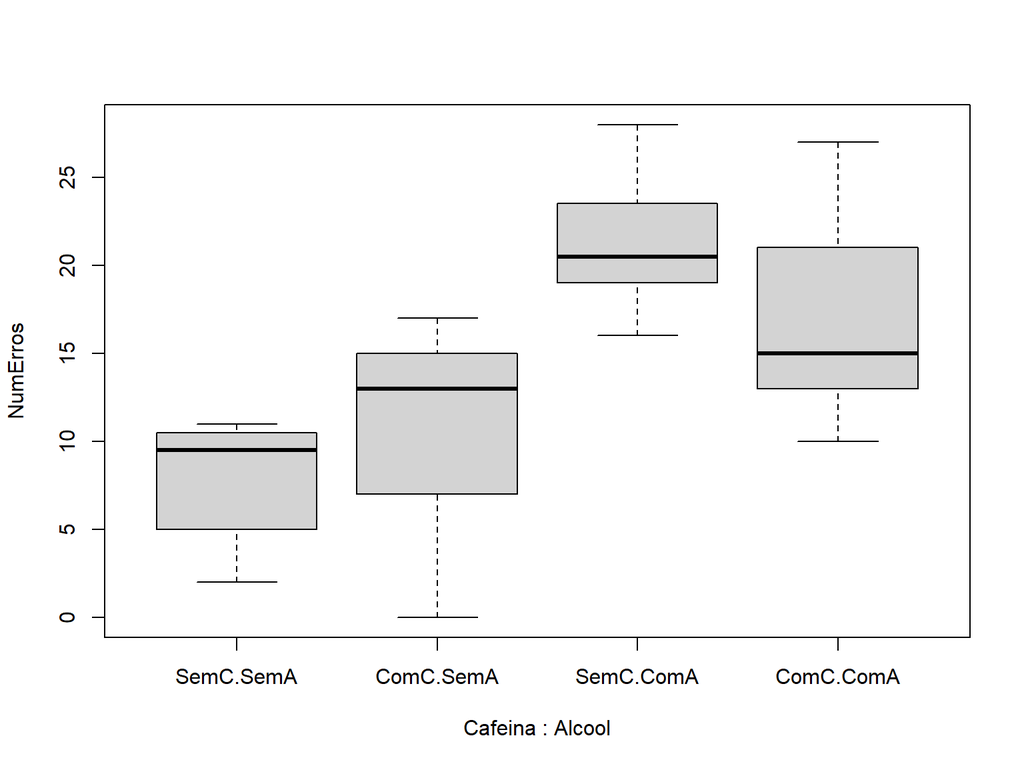

```r
boxplot(NumErros~Cafeina+Alcool,
        data=Dados,
        ylab="NumErros")
```

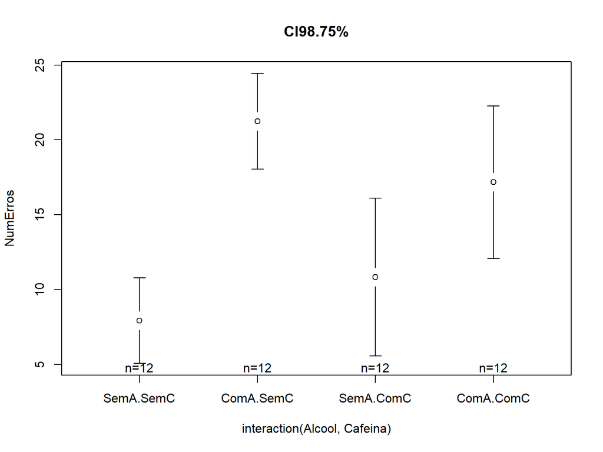

```r
alfaBonf <- alfa/(length(unique(Dados$Cafeina))*
                  length(unique(Dados$Alcool)))
gplots::plotmeans(NumErros~interaction(Alcool,Cafeina),
                  data=Dados,
                  p=1-alfaBonf,
                  main=paste("CI",round((1-alfaBonf)*100,4),"%",sep=""),
                  barcol="black",
                  connect=FALSE,)
```

```r
cat("\nAssumptions")
```

```
Assumptions
```

```r
cat("\nNormality")
```

```
Normality
```

```r
norm.test <- by(data=Dados$NumErros,
                INDICES=list("Alcool" = Dados$Alcool,
                     "Cafeina" = Dados$Cafeina),
                FUN=shapiro.test)
print(norm.test)
```

```
Alcool: SemA
Cafeina: SemC

    Shapiro-Wilk normality test

data:  dd[x, ]
W = 0.84029, p-value = 0.02792

------------------------------------------------------------
Alcool: ComA
Cafeina: SemC

    Shapiro-Wilk normality test

data:  dd[x, ]
W = 0.93036, p-value = 0.384

------------------------------------------------------------
Alcool: SemA
Cafeina: ComC

    Shapiro-Wilk normality test

data:  dd[x, ]
W = 0.84711, p-value = 0.03382

------------------------------------------------------------
Alcool: ComA
Cafeina: ComC

    Shapiro-Wilk normality test

data:  dd[x, ]
W = 0.89979, p-value = 0.1576
```

```r
cat("\nHomoscedasticity")
```

```
Homoscedasticity
```

```r
homoc.test <- car::leveneTest(NumErros~Alcool*Cafeina,
                              data=Dados)
print(homoc.test)
```

```
Levene's Test for Homogeneity of Variance (center = median)
      Df F value Pr(>F)
group  3  1.3621 0.2668
      44
```

```r
cat("\nFisher's Bifatorial independent ANOVA")
```

```
Fisher's Bifatorial independent ANOVA
```

```r
# ANOVA bifatorial independente de Fisher

cat("\nStatistical analysis: omnibus test")
```

```
Statistical analysis: omnibus test
```

```r
# teste omnibus: `lm`, `car::Anova`
modelo <- lm(NumErros ~ Alcool*Cafeina,
             data=Dados)
cat("\nANOVA")
```

```
ANOVA
```

```r
print(anv <- car::Anova(modelo))
```

```
Anova Table (Type II tests)

Response: NumErros
                Sum Sq Df F value   Pr(>F)
Alcool         1160.33  1 47.6924 1.57e-08 ***
Cafeina           4.08  1  0.1678  0.68403
Alcool:Cafeina  147.00  1  6.0420  0.01798 *
Residuals      1070.50 44
---
Signif. codes:  0 '***' 0.001 '**' 0.01 '*' 0.05 '.' 0.1 ' ' 1
```

```r
print(reg <- summary(modelo))
```

```
Call:
lm(formula = NumErros ~ Alcool * Cafeina, data = Dados)

Residuals:
    Min      1Q  Median      3Q     Max
-10.833  -2.396   0.125   3.771   9.833

Coefficients:
                       Estimate Std. Error t value Pr(>|t|)
(Intercept)               7.917      1.424   5.560 1.49e-06 ***
AlcoolComA               13.333      2.014   6.621 4.11e-08 ***
CafeinaComC               2.917      2.014   1.448    0.155
AlcoolComA:CafeinaComC   -7.000      2.848  -2.458    0.018 *
---
Signif. codes:  0 '***' 0.001 '**' 0.01 '*' 0.05 '.' 0.1 ' ' 1

Residual standard error: 4.932 on 44 degrees of freedom
Multiple R-squared:  0.5506,    Adjusted R-squared:  0.5199
F-statistic: 17.97 on 3 and 44 DF,  p-value: 9.277e-08
```

```r
cat("R^2 = eta^2 omnibus", reg$r.squared)
```

```
R^2 = eta^2 omnibus 0.550572
```

```r
print(effectsize::interpret_eta_squared(reg$r.squared))
```

```
[1] "large"
(Rules: field2013)
```

```r
eta2 <- effectsize::eta_squared(anv,
                                partial=FALSE,
                                generalized=FALSE,
                                ci=1-alfa/3,
                                alternative="two.sided",
                                verbose=TRUE)
eta2$interpret <- effectsize::interpret_eta_squared(eta2$Eta2)
print(eta2, digits=6)
```

```
# Effect Size for ANOVA (Type II)

Parameter      |     Eta2 |          98.3333% CI |  interpret
-------------------------------------------------------------
Alcool         | 0.487143 | [0.221913, 0.665274] |      large
Cafeina        | 0.001714 | [0.000000, 0.003486] | very small
Alcool:Cafeina | 0.061715 | [0.000000, 0.278859] |     medium
```

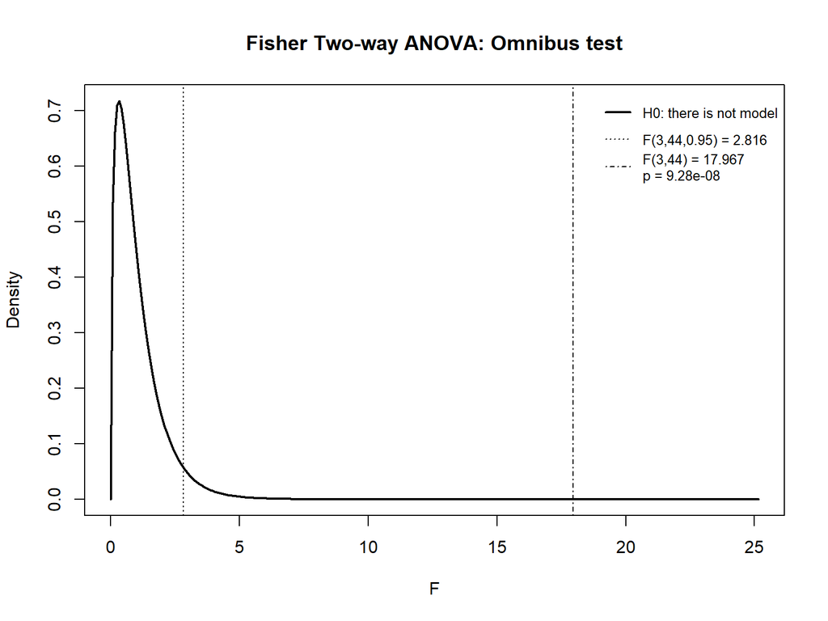

```r
# grafico do teste F
fobs <- reg$fstatistic[1]
dfn <- reg$fstatistic[2]
dfd <- reg$fstatistic[3]
fc <- qf(1-alfa, dfn, dfd)
p <- 1-pf(fobs, dfn, dfd)
if (p < 1e-4)
{
  p <- sprintf("%.2e",p)
} else
{
  p <- sprintf("%.4f",p)
}
f <- seq(0,1.4*max(fc,fobs),length.out=300)
densf <- df(f, dfn, dfd)
plot(f, densf,
     main="Fisher Two-way ANOVA: Omnibus test",
     xlab="F", ylab="Density",
     lwd=2, type="l")
abline(v=fc, lty=3)
abline(v=fobs, lty=4)
legend("topright",
       c("H0: there is not model",
         paste("F(",dfn,",",dfd,",",1-alfa,") = ",round(fc,3),sep=""),
         paste("F(",dfn,",",dfd,") = ",round(fobs,3),"\n",
               "p = ",p,sep="")
       ),
       lwd=c(2,1,1), lty=c(1,3,4),
       cex=0.8,
       bty="n")
```

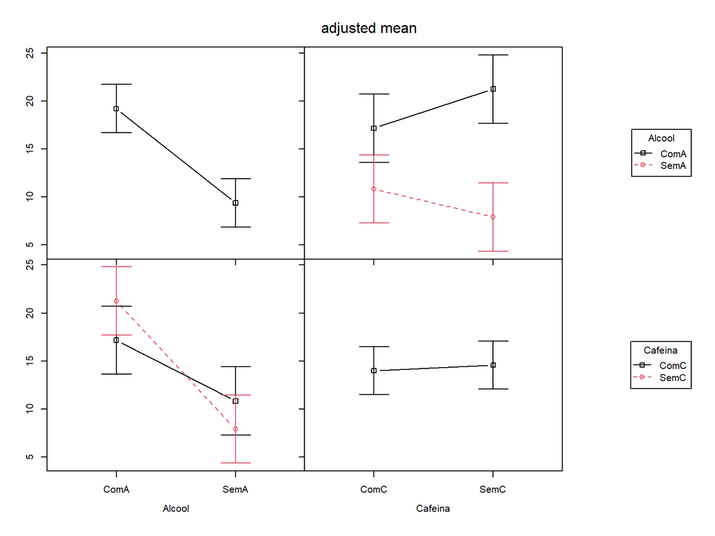

```r
# Grafico de perfil de médias
o.par <- par()
fit.means <- phia::interactionMeans(modelo)
plot(fit.means,
     errorbar=paste0("ci",
                     round((1-alfaBonf)*100,4)),
     abbrev.levels=TRUE)
par(o.par)
```

```
NOTE: Cafeina is not a high-order term in the model
```

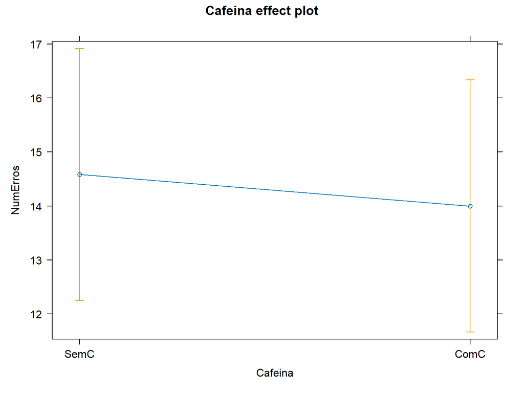

```r
plot(effects::effect(c("Cafeina"), modelo, confidence.level=1-alfa/
                       length(unique(Dados$Cafeina))),
     ci.style = "bars")
```

```
NOTE: Alcool is not a high-order term in the model
```

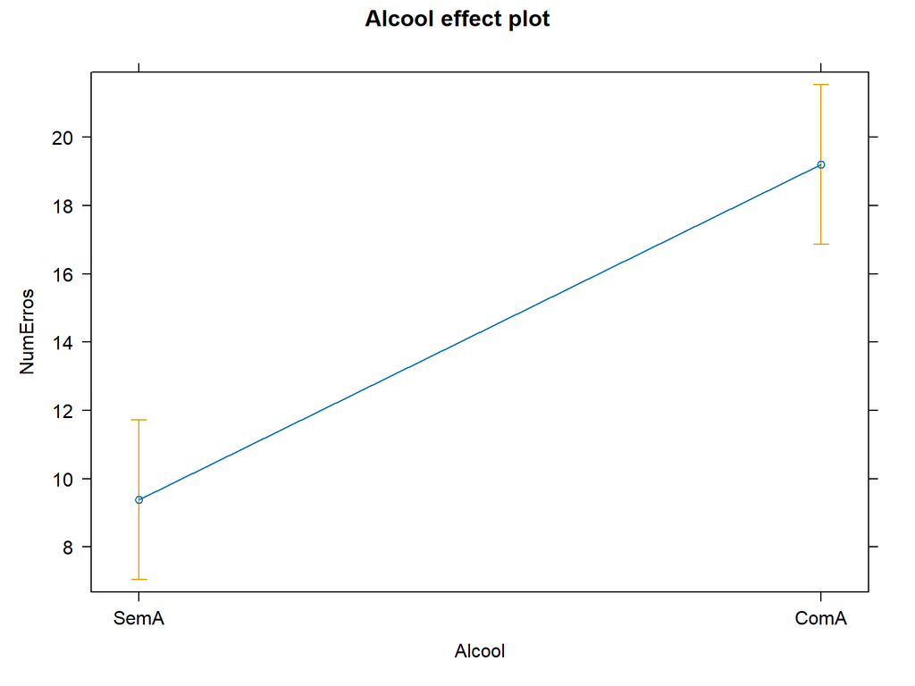

```r
plot(effects::effect(c("Alcool"), modelo, confidence.level=1-alfa/
                       length(unique(Dados$Alcool))),
     ci.style = "bars")
```

```
NOTE: CafeinaAlcool does not appear in the model
```

```
NOTE: CafeinaAlcool is not a high-order term in the model
```

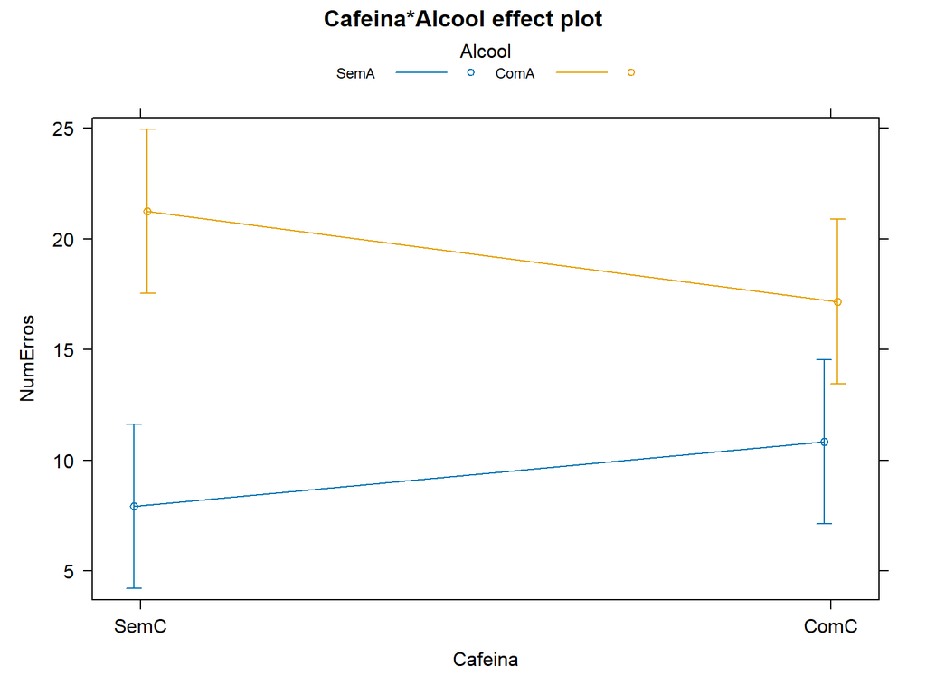

```r
plot(effects::effect(c("Cafeina", "Alcool"), modelo,
                     confidence.level=1-alfaBonf),
     multiline = TRUE, ci.style = "bars")
```

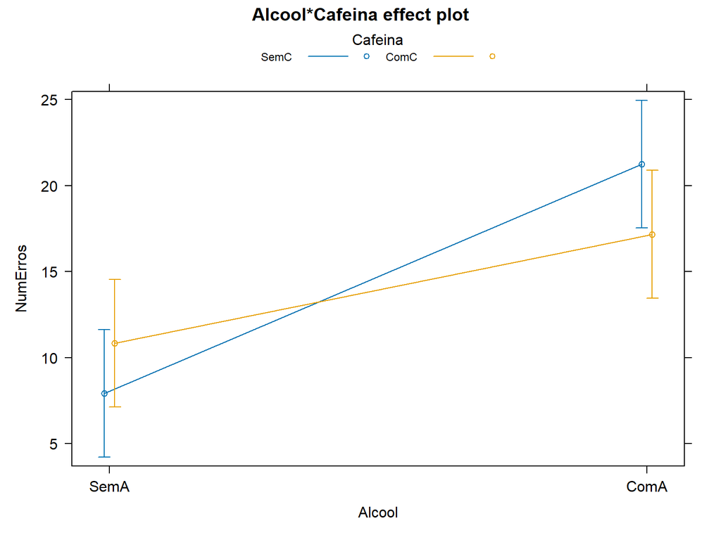

```r
plot(effects::allEffects(modelo,
                         confidence.level=1-alfaBonf),
     multiline = TRUE, ci.style = "bars")
```

```r
cat("\nSimple main effects: global")
```

```
Simple main effects: global
```

```r
cat("\n\t- Alcool at Cafeina levels\n")
```

```
    - Alcool at Cafeina levels
```

```r
print(phia::testInteractions(modelo, fixed="Cafeina", across="Alcool"))
```

```
F Test:
P-value adjustment method: holm
             Value     SE     Df Sum of Sq      F    Pr(>F)
SemC      -13.3333  2.014    1.0   1066.67 43.842 8.225e-08 ***
ComC       -6.3333  2.014    1.0    240.67  9.892  0.002973 **
Residuals          44.000 1070.5
---
Signif. codes:  0 '***' 0.001 '**' 0.01 '*' 0.05 '.' 0.1 ' ' 1
```

```r
cat("\n\t- Cafeina at Alcool levels\n")
```

```
    - Cafeina at Alcool levels
```

```r
print(phia::testInteractions(modelo, fixed="Alcool", across="Cafeina"))
```

```
F Test:
P-value adjustment method: holm
            Value     SE     Df Sum of Sq      F  Pr(>F)
SemA      -2.9167  2.014    1.0    51.042 2.0979 0.15459
ComA       4.0833  2.014    1.0   100.042 4.1119 0.09733 .
Residuals         44.000 1070.5
---
Signif. codes:  0 '***' 0.001 '**' 0.01 '*' 0.05 '.' 0.1 ' ' 1
```

```r
cat("\nPost hoc tests")
```

```
Post hoc tests
```

```r
cat("\n\tAlcool:Cafeina")
```

```
    Alcool:Cafeina
```

```r
EMM.AC <- emmeans::emmeans(modelo,
                           specs=pairwise~"Alcool:Cafeina",
                           adjust="holm",
                           level=1-alfa)
print(summary(EMM.AC$emmeans))
```

```
 Alcool Cafeina emmean   SE df lower.CL upper.CL
 SemA   SemC      7.92 1.42 44     5.05     10.8
 ComA   SemC     21.25 1.42 44    18.38     24.1
 SemA   ComC     10.83 1.42 44     7.96     13.7
 ComA   ComC     17.17 1.42 44    14.30     20.0

Confidence level used: 0.95
```

```r
print(summary(EMM.AC$contrasts, infer=TRUE))
```

```
 contrast              estimate   SE df lower.CL upper.CL t.ratio p.value
 SemA SemC - ComA SemC   -13.33 2.01 44   -18.90    -7.77  -6.621  <.0001
 SemA SemC - SemA ComC    -2.92 2.01 44    -8.48     2.65  -1.448  0.1546
 SemA SemC - ComA ComC    -9.25 2.01 44   -14.81    -3.69  -4.594  0.0001
 ComA SemC - SemA ComC    10.42 2.01 44     4.85    15.98   5.173  <.0001
 ComA SemC - ComA ComC     4.08 2.01 44    -1.48     9.65   2.028  0.0973
 SemA ComC - ComA ComC    -6.33 2.01 44   -11.90    -0.77  -3.145  0.0089

Confidence level used: 0.95
Conf-level adjustment: bonferroni method for 6 estimates
P value adjustment: holm method for 6 tests
```

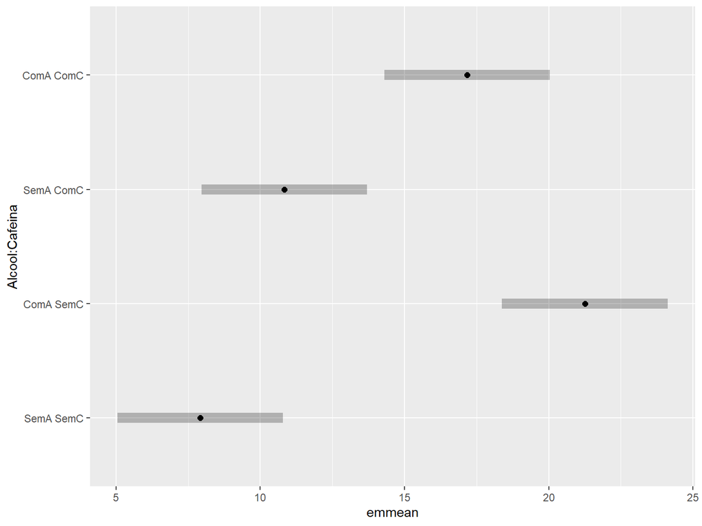

```r
print(plot(EMM.AC$emmeans,
           colors="black"))
```

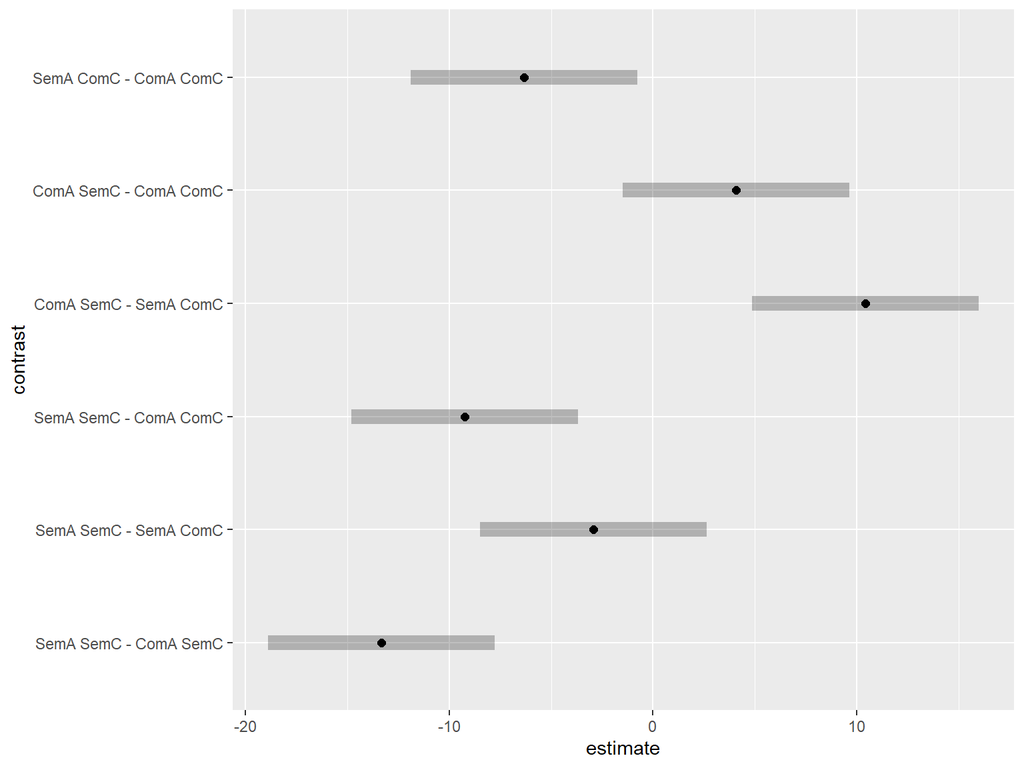

```r
print(plot(EMM.AC$contrasts,
           colors="black"))
```

```r
print(multcomp::cld(object=EMM.AC$emmeans,
                    level=1-alfa,
                    adjust="holm",
                    Letters=letters,
                    alpha=alfa))
```

```
 Alcool Cafeina emmean   SE df lower.CL upper.CL .group
 SemA   SemC      7.92 1.42 44     4.21     11.6  a
 SemA   ComC     10.83 1.42 44     7.12     14.5  a
 ComA   ComC     17.17 1.42 44    13.46     20.9   b
 ComA   SemC     21.25 1.42 44    17.54     25.0   b

Confidence level used: 0.95
Conf-level adjustment: bonferroni method for 4 estimates
P value adjustment: holm method for 6 tests
significance level used: alpha = 0.05
NOTE: If two or more means share the same grouping symbol,
      then we cannot show them to be different.
      But we also did not show them to be the same.
```

```r
cat("\n\tAlcool")
```

```
    Alcool
```

```r
EMM.A <- emmeans::emmeans(modelo,
                          specs=pairwise~"Alcool",
                          adjust="holm",
                          level=1-alfa)
```

```
NOTE: Results may be misleading due to involvement in interactions
```

```r
print(summary(EMM.A$emmeans))
```

```
 Alcool emmean   SE df lower.CL upper.CL
 SemA     9.38 1.01 44     7.35     11.4
 ComA    19.21 1.01 44    17.18     21.2

Results are averaged over the levels of: Cafeina
Confidence level used: 0.95
```

```r
print(summary(EMM.A$contrasts, infer=TRUE))
```

```
 contrast    estimate   SE df lower.CL upper.CL t.ratio p.value
 SemA - ComA    -9.83 1.42 44    -12.7    -6.96  -6.906  <.0001

Results are averaged over the levels of: Cafeina
Confidence level used: 0.95
```

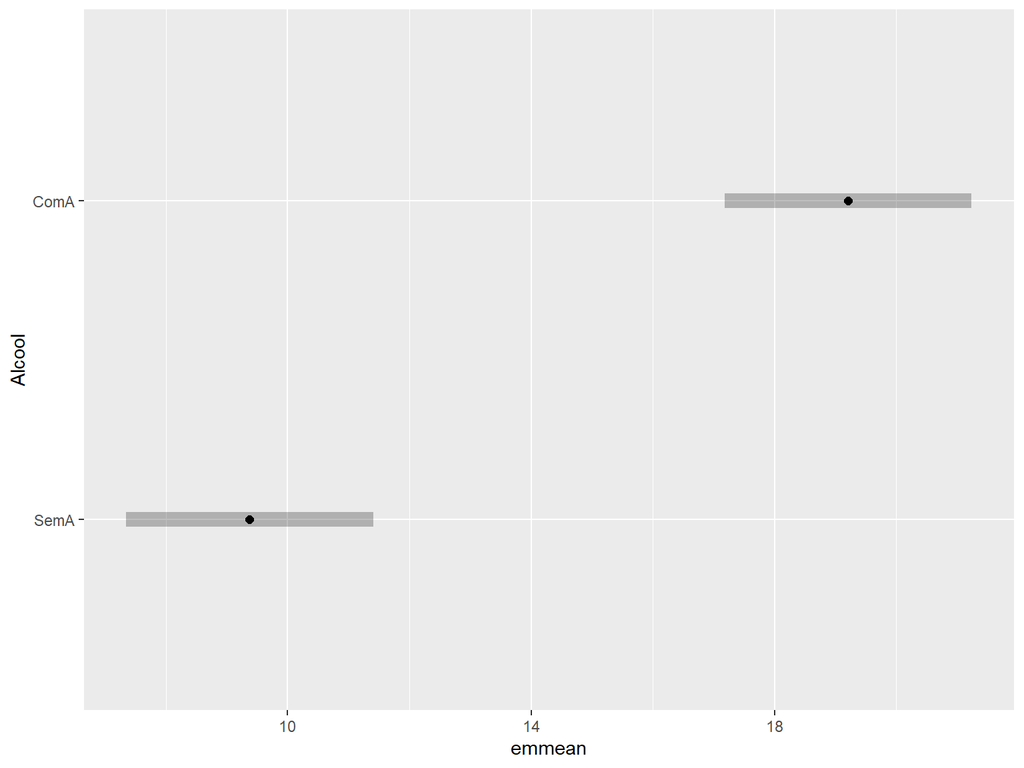

```r
print(plot(EMM.A$emmeans,
           colors="black"))
```

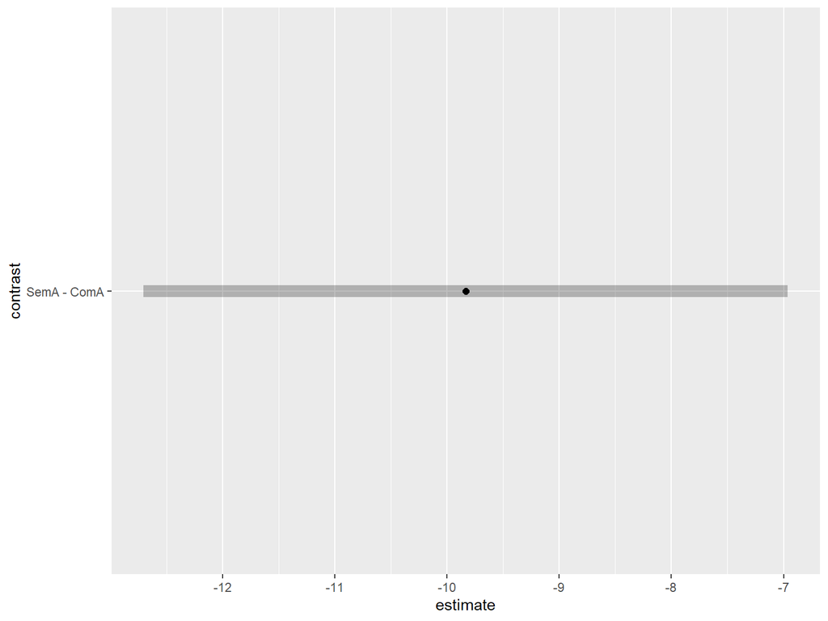

```r
print(plot(EMM.A$contrasts,
           colors="black"))
```

```r
print(multcomp::cld(object=EMM.A$emmeans,
                    level=1-alfa,
                    adjust="holm",
                    Letters=letters,
                    alpha=alfa))
```

```
 Alcool emmean   SE df lower.CL upper.CL .group
 SemA     9.38 1.01 44     7.04     11.7  a
 ComA    19.21 1.01 44    16.87     21.5   b

Results are averaged over the levels of: Cafeina
Confidence level used: 0.95
Conf-level adjustment: bonferroni method for 2 estimates
significance level used: alpha = 0.05
NOTE: If two or more means share the same grouping symbol,
      then we cannot show them to be different.
      But we also did not show them to be the same.
```

```r
cat("\n\tCafeina")
```

```
    Cafeina
```

```r
EMM.C <- emmeans::emmeans(modelo,
                          specs=pairwise~"Cafeina",
                          adjust="holm",
                          level=1-alfa)
```

```
NOTE: Results may be misleading due to involvement in interactions
```

```r
print(summary(EMM.C$emmeans))
```

```
 Cafeina emmean   SE df lower.CL upper.CL
 SemC      14.6 1.01 44     12.6     16.6
 ComC      14.0 1.01 44     12.0     16.0

Results are averaged over the levels of: Alcool
Confidence level used: 0.95
```

```r
print(summary(EMM.C$contrasts, infer=TRUE))
```

```
 contrast    estimate   SE df lower.CL upper.CL t.ratio p.value
 SemC - ComC    0.583 1.42 44    -2.29     3.45   0.410  0.6840

Results are averaged over the levels of: Alcool
Confidence level used: 0.95
```

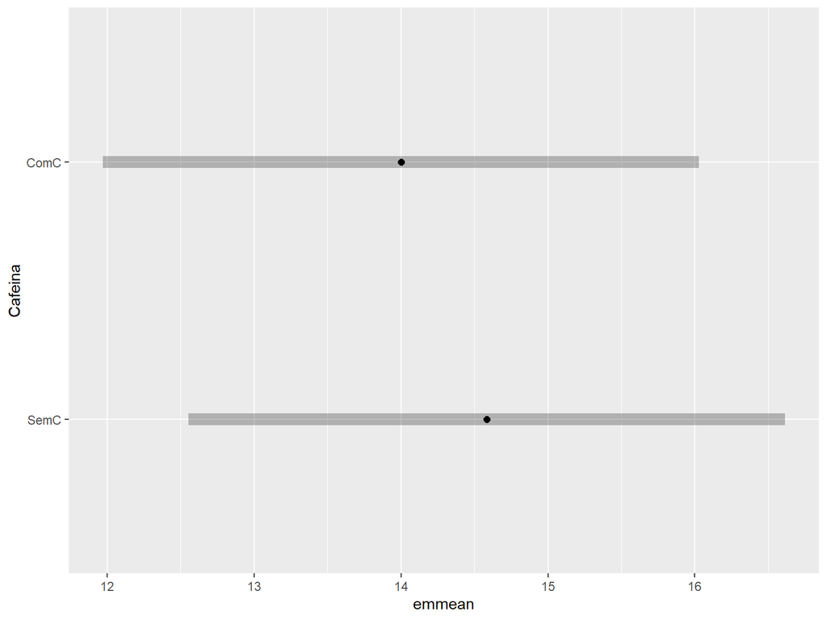

```r
print(plot(EMM.C$emmeans,
           colors="black"))
```

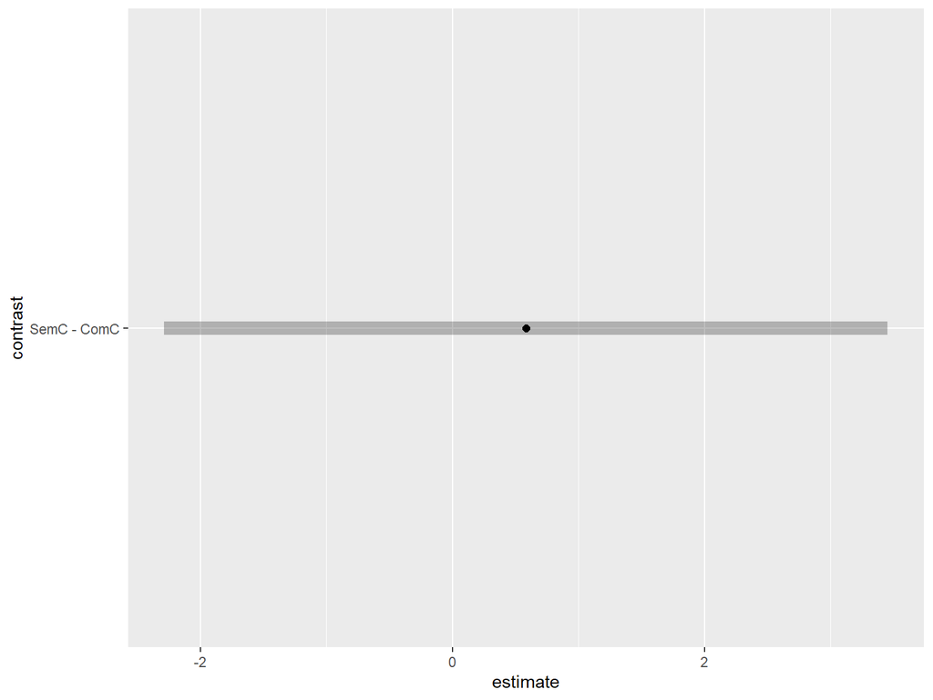

```r
print(plot(EMM.C$contrasts,
           colors="black"))
```

```r
print(multcomp::cld(object=EMM.C$emmeans,
                    level=1-alfa,
                    adjust="holm",
                    Letters=letters,
                    alpha=alfa))
```

```
 Cafeina emmean   SE df lower.CL upper.CL .group
 ComC      14.0 1.01 44     11.7     16.3  a
 SemC      14.6 1.01 44     12.2     16.9  a

Results are averaged over the levels of: Alcool
Confidence level used: 0.95
Conf-level adjustment: bonferroni method for 2 estimates
significance level used: alpha = 0.05
NOTE: If two or more means share the same grouping symbol,
      then we cannot show them to be different.
      But we also did not show them to be the same.
```

Adiante veremos ANOVA relacionada (com dois fatores intraparticipantes) e mista (com um fator intra e outro entre participantes):

- estas suposições não são testáveis para a ANOVA relacionada.
- servem apenas para o fator entre participantes para a ANOVA mista.

A função `lm()` implementa o modelo. Neste caso é um *general linear model* (GLM) porque testa efeitos fixos de fatores, tratando `NumErros` em função (`~`) de `Alcool` interagindo (`*`) com `Cafeina`. `NumErros` é a VD, intervalar. `Alcool` e `Cafeina` são os fatores nominais.

Esta forma de escrever a interação é equivalente à sintaxe na qual os efeitos são explicitamente exibidos (exceto o termo de erro, que é inerente ao modelo):

```r
modelo <- lm(NumErros ~ Alcool+Cafeina+Alcool:Cafeina, data=Dados)
modelo <- lm(NumErros ~ Alcool*Cafeina, data=Dados)
modelo <- lm(NumErros ~ (Alcool+Cafeina)^2, data=Dados)
```

Portanto, `NumErros` é tratado em função dos efeitos principais do `Alcool` e da `Cafeina`, e também em função do efeito de interação `Alcool:Cafeina`.

Este é o teste *omnibus*, e utilizamos apenas o valor *p* associado à estatística $F$ da saída da função `lm` (neste caso, rejeita-se a hipótese nula de ausência de modelo).

O valor de $R^2$ que aparece nesta saída corresponde à estimativa pontual do tamanho de efeito *omnibus* *a posteriori*.

Observe que obtivemos esta saída estabelecendo o modelo com `lm` e exibindo no formato de regressão com `summary()`. Vamos denominar este procedimento de “Regressão da ANOVA”.

A regressão funciona como um teste *omnibus*, cuja hipótese nula é a não existência de um modelo.

Para o nível de significância adotado ($\alpha=0.05$), o valor *p* rejeita a hipótese nula (a hipótese alternativa é a violação de qualquer igualdade), portanto existe modelo, significando que a estrutura proposta detecta a existência de associação entre os efeitos fixos dos fatores e a VD.

$R^2$ (

```
Multiple
R-squared
```

) é a porcentagem da variância da VD explicada pelos efeitos do modelo e, portanto, é um tamanho de efeito que equivale ao $\eta^2$ global.

### Tabela ANOVA da ANOVA Bifatorial

Como existe modelo, podemos verificar os efeitos na saída ANOVA, para explicitamente podermos definir a rejeição ou não rejeição de cada uma das hipóteses. Utilizamos o resultado de `lm` no formato de ANOVA exibido com a função `car::Anova`, que denominaremos, aqui, de “ANOVA da ANOVA”.

Há parâmetros para a função `car::Anova`. O parâmetro `type=2` é o *default*. Estes tipos são maneiras diferentes de particionar a variância total da VD entre os efeitos elencados no modelo.

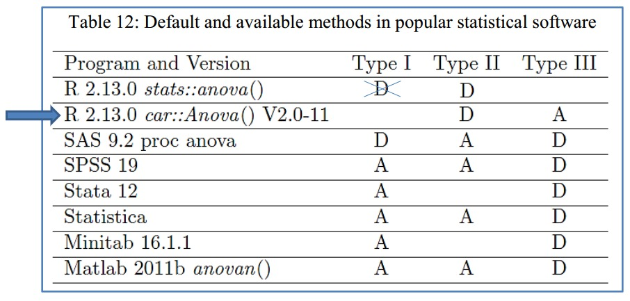

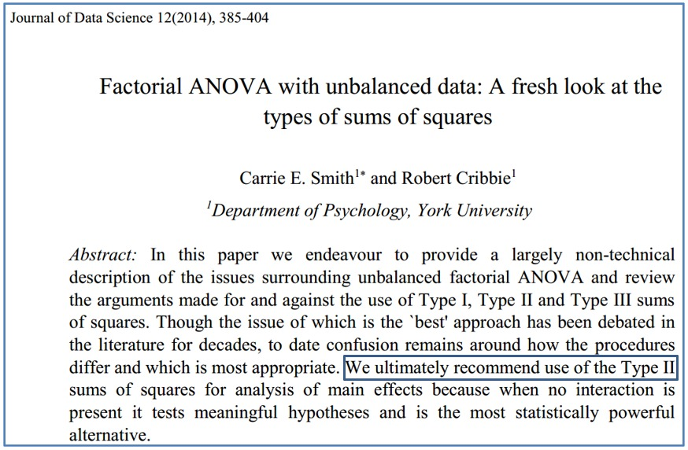

Existe também o parâmetro `white.adjust=TRUE` serve para executar método mais robusto, com correção para heterocedasticidade (a mesma que utilizamos anteriormente com ANOVA unifatorial). Não o utilizamos aqui por coerência, pois os testes *post hoc* que são realizados na ANOVA bifatorial independente de Fisher não usam o mesmo tipo de correção.

Caso prefira, existe a função `anova` que está disponível no RStudio sem que se chame seu pacote `stats`, mais limitada que a `car::Anova` (por não oferecer correção para heterocedasticidade) e que também utiliza tipo 2 por *default* (portanto, neste exemplo, mostraria resultados idênticos). Cuidado com a função `anova`, pois os valores *p* podem variar em função da ordem dos fatores na fórmula do modelo. A função `car::Anova` faz os valores *p* serem invariantes com relação à ordem dos fatores na fórmula do modelo.

#### Efeito de interação

O teste do modelo como um todo implica em testar implicitamente todas as hipóteses nulas envolvidas na ANOVA:

$$H_{0,\text{Alcool}}: \mu_{\text{SemA}} =
\mu_{\text{ComA}}$$
$$H_{0,\text{Cafeina}}: \mu_{\text{SemC}} =
\mu_{\text{ComC}}$$
$$H_{0,\text{Alcool:Cafeina}}: \text{ausência de
efeito de interação}$$

A primeira hipótese a ser verificada é o efeito de interação dos fatores em `Alcool:Cafeina`. O valor *p* é 0.01798.

Se o nível de significância adotado é 0.01, a hipótese nula do efeito de interação não é rejeitada. Nesta situação, os valores p dos efeitos principais dos fatore `Alcool` e `Cafeína` pode ser comparados com o nível de significância adotado. Se o fator tem três ou mais níveis, podem ser realizados os testes *post hoc*.

Se o nível de significância adotado é 0.05, rejeita-se a hipótese nula de ausência de efeito. Na presença de efeito de interação entre Cafeína e Álcool, não podemos considerar a significância estatística dos efeitos isolados que aparecem nas linhas `Alcool` e `Cafeina` nesta saída.

Podemos, apenas, considerar seus tamanhos de efeito, os $\eta^2$ parciais, que são as porcentagens da variância da VD que são explicadas pelos respectivos efeitos. Cada $\eta$ parcial é uma correlação de Pearson parcial absoluta implícita entre o respectivo efeito e a VD. Como há interação de efeitos, existem redundâncias que fazem com que a soma dos $\eta^2$ parciais não seja necessariamente igual ao $\eta^2$ global.

#### Efeito principal simples

Como houve efeito de interação entre Cafeína e Álcool, precisamos estudar os efeitos principais simples, que é a verificação de cada um efeitos de um fator em todos os níveis do outro fator.

Neste exemplo, em que ocorreu interação usando o nível de significância de 0.05, a verificação dos efeitos principais simples de Álcool e Cafeína é feito com funções R que fornecem os valores *p* já ajustados, portanto podemos compará-los diretamente com $\alpha=0.05$. Neste exemplo, verificamos que o efeito do Álcool é significante nos dois níveis de cafeína, portanto podemos dizer que o efeito principal do Álcool é genuíno. Ao contrário, o efeito da Cafeína não foi significante nas condições com ou sem Álcool, portanto não se trata de um efeito principal genuíno. Isto equivale a dizer Cafeína não modifica a VD de acordo com o nível de Álcool.

Os testes de efeito principal simples com a função `phia::testInteractions` e `emmeans::emmeans`.

Portanto, a pergunta que foi feita inicialmente: Se beber, tomar café para dirigir? é respondida, de acordo com esta análise:

Segundo este estudo, não há evidência amostral de que a ingestão de Cafeína contrabalança o efeito do Álcool para que alguém possa dirigir alcoolizado.

Em geral, os trabalhos publicados não têm mais do que três fatores. Imagine um estudo com Álcool, Cafeína e Glicose, cada um com dois níveis. O total de efeitos é $2×2×2=8$:

- efeitos principais:
  - Álcool (com ou sem)
  - Cafeína (com ou sem)
  - Glicose (com ou sem)
- efeitos de interação de ordem 2:
  - Álcool:Cafeína
  - Álcool:Glicose
  - Cafeína:Glicose
- efeito de interação de ordem 3:
  - Álcool:Cafeína:Glicose
- efeito do termo de erro.

Genericamente, uma ANOVA $a_1×a_2×\cdots×a_k$ tem $2^k$ efeitos, sendo que $a_i$ é o número de níveis do fator $i$. Assim, $a_1×a_2×\cdots×a_k$ é número de tratamentos/condições experimentais, divididos em:

- $k$ efeitos principais, i.e., $C(k,1)$ ou `choose(k,1)`
- $k$ efeitos de interação de ordem 2, i.e., $C(k,2)$ ou `choose(k,2)`

…

- $k$ efeitos de interação de ordem $k-1$, i.e., $C(k,k-1)$ ou `choose(k,k-1)`
- $1$ efeito de interação de ordem $k$, i.e., $C(k,k)$ ou `choose(k,k)`
- $1$ efeito de erro, i.e., $C(k,0)$ ou `choose(k,0)`

Como regra heurística em ANOVA com mais de três fatores analisam-se os efeitos de interação até ordem 3, sendo que os efeitos de interação podem ser escolhidos para análise.

Como foi visto, os testes de efeitos de ordem inferior só podem ser considerados se não há efeitos de ordem superior estatisticamente significantes mas podem ser considerados diretamente se o efeito de interação não é estatisticamente significante.

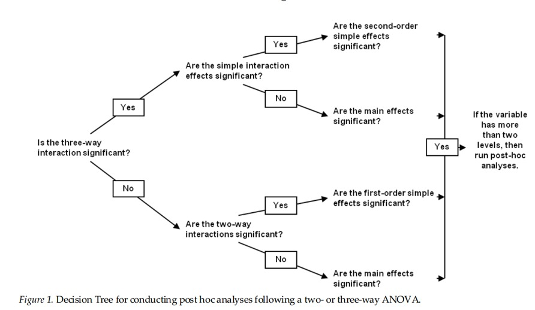

Howell GT, Lacroix GL (2012) Decomposing interactions using GLM in combination with the COMPARE, LMATRIX and MMATRIX subcommands in SPSS. *Tutorials in Quantitative Methods for Psychology* 8(1):1-22. DOI:10.20982/tqmp.08.1.p001

## ANOVA multifatorial independente de Fisher-White

- ANOVA multifatorial independente de Fisher-White (heterocedástico):
  - teste *omnibus*: `lm`, `car::Anova(white.adjust="hc2", ...))`, `estimatr::lm_robust(se_type="HC2", ...)`
    - testes *post hoc*: ?

O código completo está implementado em `demo_ANOVA2f_Indep_Fisher-White_AlcCaf.R`.

```
Fisher-White's Bifatorial independent ANOVA
Statistical analysis: omnibus test
ANOVA
```

```
Coefficient covariances computed by hccm()
```

```
Analysis of Deviance Table (Type II tests)

Response: NumErros
               Df      F    Pr(>F)
Alcool          1 86.504 5.951e-12 ***
Cafeina         1  0.158   0.69297
Alcool:Cafeina  1  6.042   0.01798 *
Residuals      44
---
Signif. codes:  0 '***' 0.001 '**' 0.01 '*' 0.05 '.' 0.1 ' ' 1

Call:
estimatr::lm_robust(formula = NumErros ~ Alcool * Cafeina, data = Dados,
    se_type = "HC2")

Standard error type:  HC2

Coefficients:
                       Estimate Std. Error t value  Pr(>|t|) CI Lower CI Upper
(Intercept)               7.917     0.9571   8.272 1.649e-10    5.988    9.846
AlcoolComA               13.333     1.4386   9.269 6.591e-12   10.434   16.233
CafeinaComC               2.917     2.0087   1.452 1.536e-01   -1.132    6.965
AlcoolComA:CafeinaComC   -7.000     2.8478  -2.458 1.798e-02  -12.739   -1.261
                       DF
(Intercept)            44
AlcoolComA             44
CafeinaComC            44
AlcoolComA:CafeinaComC 44

Multiple R-squared:  0.5506 ,   Adjusted R-squared:  0.5199
F-statistic: 30.86 on 3 and 44 DF,  p-value: 6.729e-11
R^2 = eta^2 omnibus = 0.550572[1] "substantial"
(Rules: cohen1988)
# Effect Size for ANOVA (Type I)

Parameter      | Eta2 (partial) |               95% CI
------------------------------------------------------
Alcool         |       0.520134 | [0.346897, 1.000000]
Cafeina        |       0.003800 | [0.000000, 1.000000]
Alcool:Cafeina |       0.120739 | [0.012097, 1.000000]

- One-sided CIs: upper bound fixed at [1.000000].
```

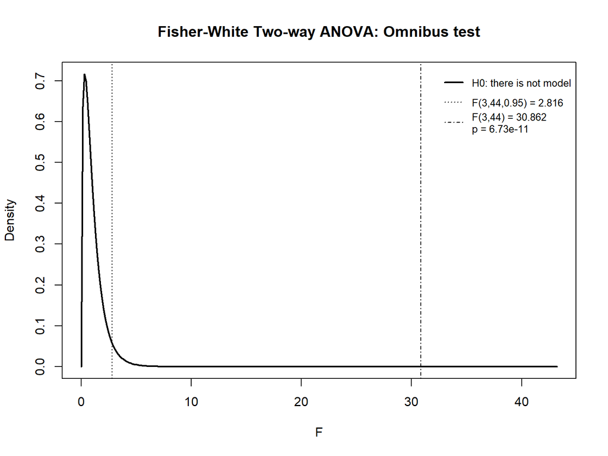

## ANOVA multifatorial independente por *Parametric Bootstrap based Generalized Test*

- ANOVA multifatorial independente por *Parametric Bootstrap based Generalized Test* (heterocedástico):
  - teste *omnibus*: `twowaytests::gpTwoWay`
    - testes *post hoc*: `twowaytests::paircompTwoWay`

O código completo está implementado em `demo_ANOVA2f_Indep_PB_AlcCaf.R`.

```r
alfa <- 0.05

Dados <- readRDS("CafeinaAlcool_entre.rds")

# ANOVA multifatorial independente por _Parametric Bootstrap based Generalized Test_:
omni_Caf <- twowaytests::gpTwoWay(NumErros ~ Cafeina*Alcool,
                                  alpha = alfa,
                                  data=Dados)
```

```
  Generalized p-value by PB method (alpha = 0.05)
--------------------------------------------------
         Factor P.value     Result
        Cafeina  0.0681 Not reject
         Alcool  0.0000     Reject
 Cafeina:Alcool  0.0213     Reject
--------------------------------------------------
```

```r
# Teste de efeito simples de Cafeina
twowaytests::paircompTwoWay(omni_Caf,
                            alpha = alfa,
                            adjust.method = "holm")
```

```
  Holm correction (alpha = 0.05) for subgroups of each Cafeina level
--------------------------------------------------------------------------------
  Cafeina Alcool(a) Alcool(b)      P.value   No difference
1    SemC      SemA      ComA 5.316791e-09          Reject
2    ComC      SemA      ComA 1.721035e-02          Reject
--------------------------------------------------------------------------------
```

```r
omni_Alc <- twowaytests::gpTwoWay(NumErros ~ Alcool*Cafeina,
                                  alpha = alfa,
                                  data=Dados)
```

```
  Generalized p-value by PB method (alpha = 0.05)
--------------------------------------------------
         Factor P.value     Result
         Alcool  0.0000     Reject
        Cafeina  0.0684 Not reject
 Alcool:Cafeina  0.0205     Reject
--------------------------------------------------
```

```r
# Teste de efeito simples de Alcool
twowaytests::paircompTwoWay(omni_Alc,
                            alpha = alfa,
                            adjust.method = "holm")
```

```
  Holm correction (alpha = 0.05) for subgroups of each Alcool level
--------------------------------------------------------------------------------
  Alcool Cafeina(a) Cafeina(b)    P.value   No difference
1   SemA       SemC       ComC 0.16475000      Not reject
2   ComA       SemC       ComC 0.05778413      Not reject
--------------------------------------------------------------------------------
```

# ANOVA bifatorial relacionada

## Planejamento

- Multifatorial para medidas repetidas
  - `WebPower::wp.rmanova`

```r
WebPower::wp.rmanova(n=NULL,
                     ng=2,
                     nm=2,
                     f=0.5,
                     alpha=0.05,
                     power=0.9,
                     type=1,
                     nscor=0.5)
```

```
Repeated-measures ANOVA analysis

           n   f ng nm nscor alpha power
    72.44536 0.5  2  2   0.5  0.05   0.9

NOTE: Power analysis for within-effect test
URL: http://psychstat.org/rmanova
```

## ANOVA bifatorial relacionada

Usando os mesmos valores do exemplo anterior (para comparação dos resultados), imagine que tenhamos apenas 12 participantes, cada um deles sendo submetido às quatro condições experimentais.

“Vale a pena observar que a MANOVA é ainda um teste válido, mesmo com modestas violações na suposição de normalidade, particularmente quando os tamanhos dos grupos são iguais e existe um número razoável de participantes em cada grupo; por “razoável” entendemos que [para um delineamento] completamente intraparticipantes, [deve haver] pelo menos 22 participantes ao todo.”

> Dancey & Reidy, 2019, p. 472

Neste exemplo aplica-se a ANOVA relacionada bifatorial. Os tratamentos são os mesmos, com a diferença importante de que todos os participantes são submetidos às quatro condições:

- com cafeína e com álcool,
- com cafeína e sem álcool,
- sem cafeína e com álcool,
- sem cafeína e sem álcool.

Dizemos, portanto, que ambos os fatores são intra participantes. Nesta modelagem da ANOVA é preciso controlar pelo participante, incluindo a variável de identificação como um efeito aleatório.

Os dados estão em `CafeinaAlcool_intra.rds`.

```r
Dados <- data.frame(readxl::read_excel("CafeinaAlcool_intra.xlsx"))
Dados$UE <- factor(Dados$UE)
Dados$Cafeina <- factor(Dados$Cafeina,
                        levels=c("SemC","ComC"))
Dados$Alcool <- factor(Dados$Alcool,
                       levels=c("SemA","ComA"))
saveRDS(Dados, "CafeinaAlcool_intra.rds")
```

```r
Dados <- readRDS("CafeinaAlcool_intra.rds")
str(Dados)
```

```
'data.frame':   48 obs. of  4 variables:
 $ UE      : Factor w/ 12 levels "1","2","3","4",..: 1 1 1 1 2 2 2 2 3 3 ...
 $ Alcool  : Factor w/ 2 levels "SemA","ComA": 1 1 2 2 1 1 2 2 1 1 ...
 $ Cafeina : Factor w/ 2 levels "SemC","ComC": 1 2 1 2 1 2 1 2 1 2 ...
 $ NumErros: num  4 15 28 10 9 8 22 11 10 17 ...
```

```r
print.data.frame(Dados)
```

```
   UE Alcool Cafeina NumErros
1   1   SemA    SemC        4
2   1   SemA    ComC       15
3   1   ComA    SemC       28
4   1   ComA    ComC       10
5   2   SemA    SemC        9
6   2   SemA    ComC        8
7   2   ComA    SemC       22
8   2   ComA    ComC       11
9   3   SemA    SemC       10
10  3   SemA    ComC       17
11  3   ComA    SemC       21
12  3   ComA    ComC       27
13  4   SemA    SemC        8
14  4   SemA    ComC        0
```

[output cut: 34 more lines]

```r
print(summary(Dados))
```

```
       UE      Alcool   Cafeina      NumErros
 1      : 4   SemA:24   SemC:24   Min.   : 0.00
 2      : 4   ComA:24   ComC:24   1st Qu.:10.00
 3      : 4                       Median :15.00
 4      : 4                       Mean   :14.29
 5      : 4                       3rd Qu.:19.25
 6      : 4                       Max.   :28.00
 (Other):24
```

```r
print(ftable(Dados[,-4]))
```

```
          Cafeina SemC ComC
UE Alcool
1  SemA              1    1
   ComA              1    1
2  SemA              1    1
   ComA              1    1
3  SemA              1    1
   ComA              1    1
4  SemA              1    1
   ComA              1    1
5  SemA              1    1
   ComA              1    1
6  SemA              1    1
   ComA              1    1
7  SemA              1    1
   ComA              1    1
8  SemA              1    1
   ComA              1    1
9  SemA              1    1
   ComA              1    1
10 SemA              1    1
   ComA              1    1
11 SemA              1    1
   ComA              1    1
12 SemA              1    1
   ComA              1    1
```

Da mesma forma que fizemos no exemplo anterior, o código completo está em `demo_ANOVA2f_dep_alccafe.R`.

## Estatística descritiva

Os dados estão no formato *long*. Observe a coluna das unidades experimentais (UE). Cada observação aparece em uma linha, mas a identificação das unidades experimentais é repetida, de forma que há apenas 12 participantes, cada um deles submetido aos quatro tratamentos.

Os gráficos que foram utilizados para a condição com dois fatores independentes não devem ser usados neste contexto, pois os intervalos de confiança dependem dos desvios-padrão e estes, por sua vez, pressupõem observações independentes. O gráfico de intervalo de confiança apresentado é o mais adequado para medidas repetidas.

## ANOVA bifatorial relacionada e tamanho de efeito

A linha que define este modelo é

```r
modelo <- lmerTest::lmer(NumErros ~ Alcool*Cafeina + (1|UE),
                         data=Dados)
```

Note o termo `(1|UE)`. Em delineamento com medidas repetidas, esta é forma de incluir a identificação do participante como um controle por meio de efeito aleatório.

A ANOVA é computada por

```r
print(anv <- car::Anova(modelo,test.statistic="F"))
```

O tamanho de efeito global ($\eta^2$) é dado por

```r
eta2 <- as.numeric(MuMIn::r.squaredGLMM(modelo)[1])
```

Estas funções são adequadas para o participante modelado como efeito aleatório.

ANOVA bifatorial relacionada mostra que há efeito de interação entre Álcool e Cafeína.

## Análise dos efeitos principais simples

A análise, neste caso, utiliza as mesmas funções do caso independente. Porém, o objeto veio de `lmerTest::lmer`.

Por ser um objeto diferente, a estatística de teste mudou, bem como os respectivos valores *p*. A conclusão ainda é a mesma: há efeito de álcool nos dois níveis de cafeína, mas não há efeito de cafeína nos dois níveis de álcool. O gráfico das médias marginais estimadas é praticamente o mesmo.

## Testes *post hoc*

Os graus de liberdade são diferentes do caso com fatores independentes. Os intervalos, neste exemplo, ficaram praticamente iguais ao anterior.

```r
source("summarySEwithin2.R")
Dados <- readRDS("CafeinaAlcool_intra.rds")
alfa <- 0.05
print(ftable(Dados[,-4]))
```

```
          Cafeina SemC ComC
UE Alcool
1  SemA              1    1
   ComA              1    1
2  SemA              1    1
   ComA              1    1
3  SemA              1    1
   ComA              1    1
4  SemA              1    1
   ComA              1    1
5  SemA              1    1
   ComA              1    1
6  SemA              1    1
   ComA              1    1
7  SemA              1    1
   ComA              1    1
8  SemA              1    1
   ComA              1    1
9  SemA              1    1
   ComA              1    1
10 SemA              1    1
   ComA              1    1
11 SemA              1    1
   ComA              1    1
12 SemA              1    1
   ComA              1    1
```

```r
print(psych::describe(NumErros ~ Alcool*Cafeina,
                      data=Dados), digits=2)
```

```
 Descriptive statistics by group
Alcool: SemA
Cafeina: SemC
         vars  n mean   sd median trimmed  mad min max range  skew kurtosis
NumErros    1 12 7.92 3.32    9.5     8.2 2.22   2  11     9 -0.63    -1.35
           se
NumErros 0.96
------------------------------------------------------------
Alcool: ComA
Cafeina: SemC
         vars  n  mean   sd median trimmed  mad min max range skew kurtosis
NumErros    1 12 21.25 3.72   20.5    21.1 2.22  16  28    12 0.49    -1.04
           se
NumErros 1.07
------------------------------------------------------------
Alcool: SemA
Cafeina: ComC
         vars  n  mean   sd median trimmed  mad min max range skew kurtosis
NumErros    1 12 10.83 6.12     13    11.3 4.45   0  17    17 -0.7    -1.08
           se
NumErros 1.77
------------------------------------------------------------
Alcool: ComA
Cafeina: ComC
         vars  n  mean   sd median trimmed  mad min max range skew kurtosis
NumErros    1 12 17.17 5.92     15    16.9 6.67  10  27    17 0.41    -1.24
           se
NumErros 1.71
```

```r
alfaBonf <- alfa/(length(unique(Dados$Alcool))*
                  length(unique(Dados$Cafeina)))
ic <- summarySEwithin2(Dados,
                       measurevar="NumErros",
                       withinvars=c("Alcool","Cafeina"),
                       idvar="UE",
                       na.rm=TRUE,
                       conf.interval=1-alfaBonf)
print(ic)
```

```
  Alcool Cafeina  N  NumErros NumErrosNormed       sd       se       ci
1   ComA    ComC 12 17.166667      17.166667 5.233198 1.510694 4.503187
2   ComA    SemC 12 21.250000      21.250000 5.034477 1.453328 4.332186
3   SemA    ComC 12 10.833333      10.833333 5.914586 1.707394 5.089523
4   SemA    SemC 12  7.916667       7.916667 4.409872 1.273020 3.794711
```

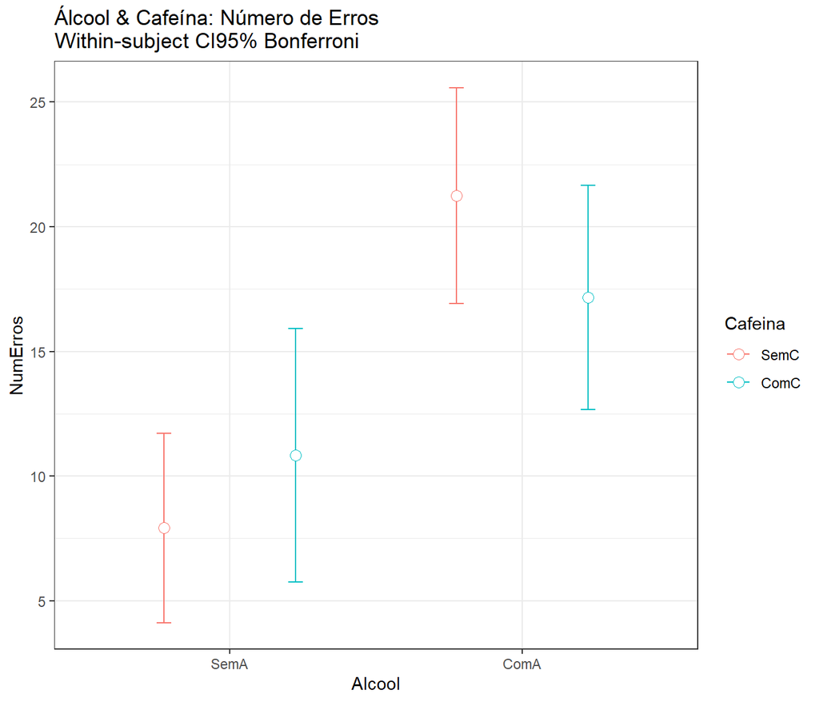

```r
grf <- ggplot2::ggplot(ic,
                       ggplot2::aes(x=Alcool,
                                    y=NumErros,
                                    colour=Cafeina)) +
  ggplot2::geom_errorbar(position=ggplot2::position_dodge(.9),
                         width=.1,
                         ggplot2::aes(ymin=NumErros-ci,
                                      ymax=NumErros+ci)) +
  ggplot2::geom_point(shape=21,
                      size=3,
                      fill="white",
                      position=ggplot2::position_dodge(.9)) +
  ggplot2::ylab("NumErros") +
  ggplot2::ggtitle("Álcool & Cafeína: Número de Erros\nWithin-subject CI95% Bonferroni") +
  ggplot2::theme_bw()
print(grf)
```

```r
modelo <- lmerTest::lmer(NumErros ~ Alcool*Cafeina + (1|UE),
                         data=Dados)
```

```
boundary (singular) fit: see help('isSingular')
```

```r
cat("\nANOVA")
```

```
ANOVA
```

```r
print(anv <- car::Anova(modelo,test.statistic="F"))
```

```
Analysis of Deviance Table (Type II Wald F tests with Kenward-Roger df)

Response: NumErros
                     F Df Df.res    Pr(>F)
Alcool         47.6924  1     33 6.888e-08 ***
Cafeina         0.1678  1     33   0.68469
Alcool:Cafeina  6.0420  1     33   0.01939 *
---
Signif. codes:  0 '***' 0.001 '**' 0.01 '*' 0.05 '.' 0.1 ' ' 1
```

```r
print(summary(modelo, correl=FALSE))
```

```
Linear mixed model fit by REML. t-tests use Satterthwaite's method [
lmerModLmerTest]
Formula: NumErros ~ Alcool * Cafeina + (1 | UE)
   Data: Dados

REML criterion at convergence: 275.2

Scaled residuals:
     Min       1Q   Median       3Q      Max
-2.19632 -0.48572  0.02534  0.76449  1.99358

Random effects:
 Groups   Name        Variance Std.Dev.
 UE       (Intercept)  0.00    0.000
 Residual             24.33    4.932
Number of obs: 48, groups:  UE, 12

Fixed effects:
                       Estimate Std. Error     df t value Pr(>|t|)
(Intercept)               7.917      1.424 44.000   5.560 1.49e-06 ***
AlcoolComA               13.333      2.014 44.000   6.621 4.11e-08 ***
CafeinaComC               2.917      2.014 44.000   1.448    0.155
AlcoolComA:CafeinaComC   -7.000      2.848 44.000  -2.458    0.018 *
---
Signif. codes:  0 '***' 0.001 '**' 0.01 '*' 0.05 '.' 0.1 ' ' 1
optimizer (nloptwrap) convergence code: 0 (OK)
boundary (singular) fit: see help('isSingular')
```

```r
cat("\nEffect size analysis")
```

```
Effect size analysis
```

```r
eta2g <- as.numeric(MuMIn::r.squaredGLMM(modelo)[1])
cat("\nTamanho de efeito: eta^2 omnibus =", eta2g)
```

```
Tamanho de efeito: eta^2 omnibus = 0.5342025
```

```r
es <- effectsize::interpret_eta_squared(eta2g)
names(es) <- c("Tamanho de efeito omnibus: estimativa pontual")
print(es)
```

```
Tamanho de efeito omnibus: estimativa pontual
                                      "large"
(Rules: field2013)
```

```r
eta2 <- effectsize::eta_squared(anv,
                                partial=FALSE,
                                generalized=FALSE,
                                ci=1-alfa/3,
                                alternative="two.sided",
                                verbose=TRUE)
eta2$interpret <- effectsize::interpret_eta_squared(eta2$Eta2)
print(eta2, digits=6)
```

```
# Effect Size for ANOVA (Type II)

Parameter      | Eta2 (partial) |          98.3333% CI |  interpret
-------------------------------------------------------------------
Alcool         |       0.591039 | [0.299078, 0.752818] |      large
Cafeina        |       0.005060 | [0.000000, 0.010255] | very small
Alcool:Cafeina |       0.154757 | [0.000000, 0.425355] |      large
```

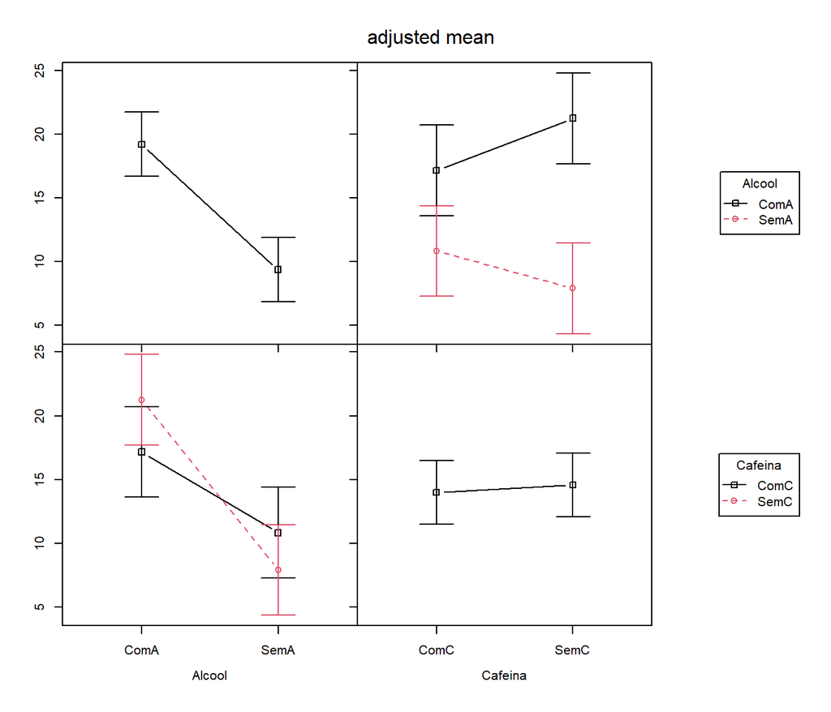

```r
# Grafico de perfis de medias
# Grafico de perfil de médias
o.par <- par()
fit.means <- phia::interactionMeans(modelo)
plot(fit.means,
     errorbar=paste0("ci",
                     round((1-alfaBonf)*100,4)),
     abbrev.levels=TRUE)
par(o.par)
```

```
NOTE: Cafeina is not a high-order term in the model
```

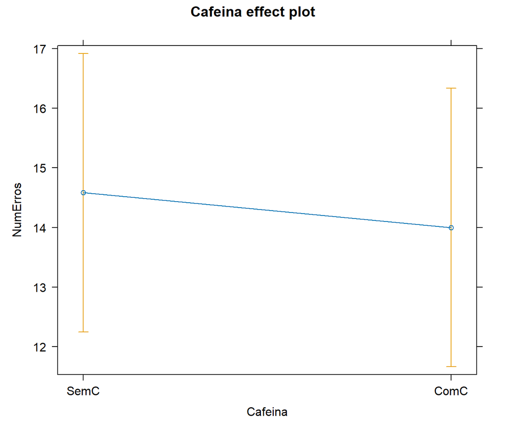

```r
plot(effects::effect(c("Cafeina"), modelo, confidence.level=1-alfa/
                       length(unique(Dados$Cafeina))),
     ci.style = "bars")
```

```
NOTE: Alcool is not a high-order term in the model
```

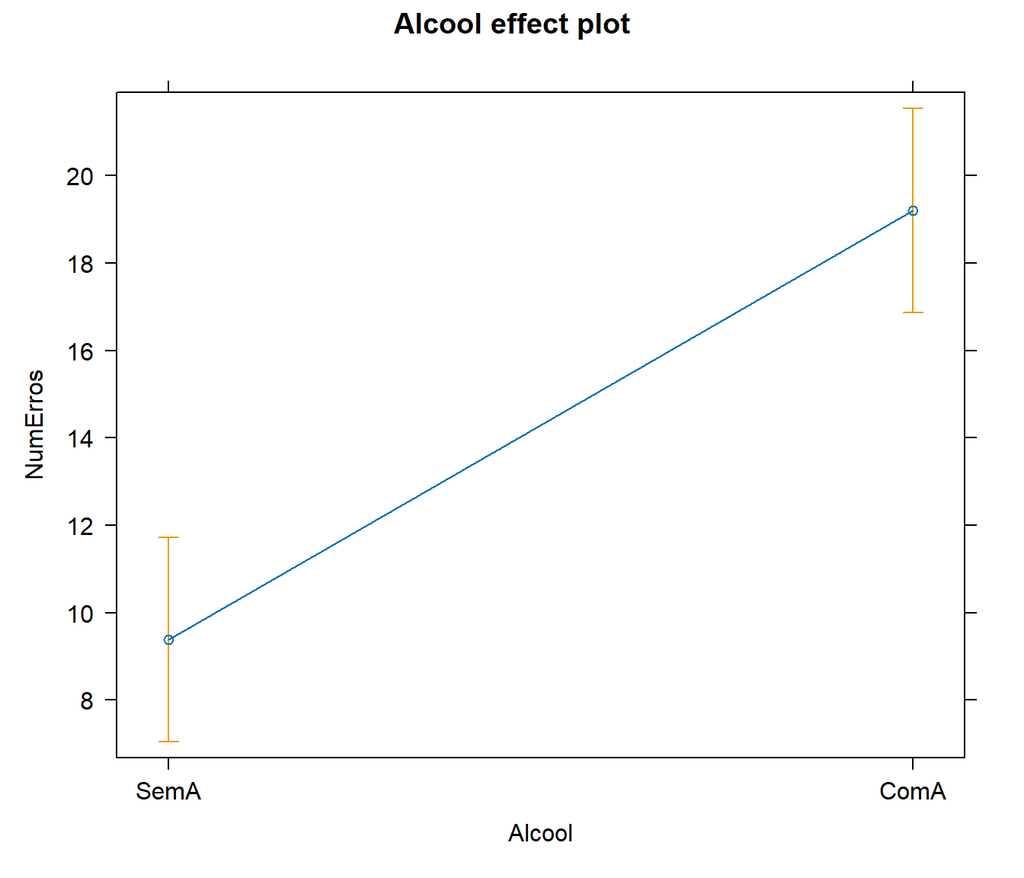

```r
plot(effects::effect(c("Alcool"), modelo, confidence.level=1-alfa/
                       length(unique(Dados$Alcool))),
     ci.style = "bars")
```

```
NOTE: CafeinaAlcool does not appear in the model
```

```
NOTE: CafeinaAlcool is not a high-order term in the model
```

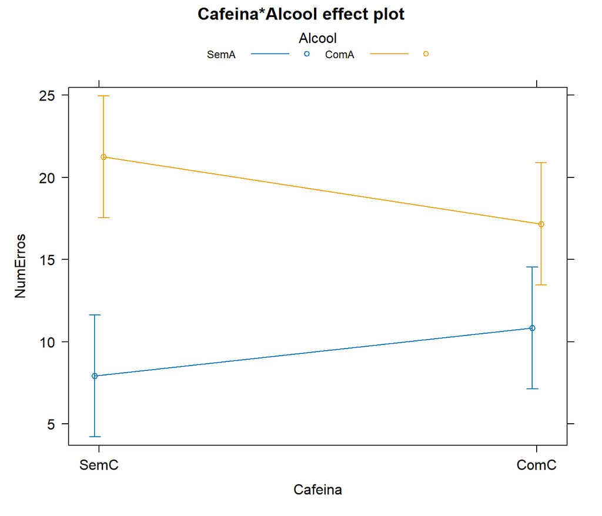

```r
plot(effects::effect(c("Cafeina", "Alcool"), modelo,
                     confidence.level=1-alfaBonf),
     multiline = TRUE, ci.style = "bars")
```

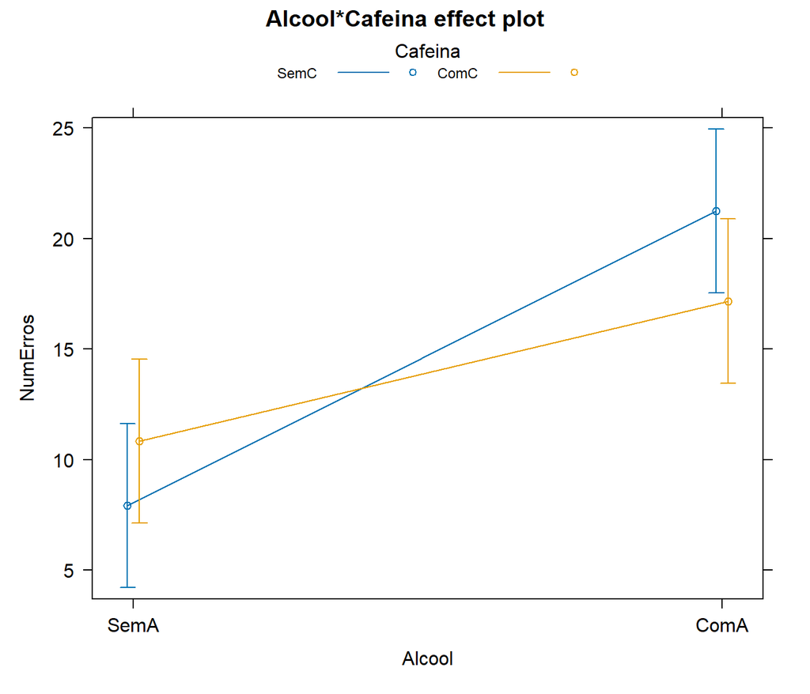

```r
plot(effects::allEffects(modelo,
                         confidence.level=1-alfaBonf),
     multiline = TRUE, ci.style = "bars")
```

```r
cat("\nSimple main effects: global")
```

```
Simple main effects: global
```

```r
cat("\n\t- Alcool at Cafeina levels\n")
```

```
    - Alcool at Cafeina levels
```

```r
print(phia::testInteractions(modelo, fixed="Cafeina", across="Alcool"))
```

```
Chisq Test:
P-value adjustment method: holm
        Value     SE Df  Chisq Pr(>Chisq)
SemC -13.3333 2.0137  1 43.842  7.118e-11 ***
ComC  -6.3333 2.0137  1  9.892    0.00166 **
---
Signif. codes:  0 '***' 0.001 '**' 0.01 '*' 0.05 '.' 0.1 ' ' 1
```

```r
cat("\n\t- Cafeina at Alcool levels\n")
```

```
    - Cafeina at Alcool levels
```

```r
print(phia::testInteractions(modelo, fixed="Alcool", across="Cafeina"))
```

```
Chisq Test:
P-value adjustment method: holm
       Value     SE Df  Chisq Pr(>Chisq)
SemA -2.9167 2.0137  1 2.0979    0.14750
ComA  4.0833 2.0137  1 4.1119    0.08516 .
---
Signif. codes:  0 '***' 0.001 '**' 0.01 '*' 0.05 '.' 0.1 ' ' 1
```

```r
cat("\nPost hoc tests")
```

```
Post hoc tests
```

```r
cat("\n\tAlcool:Cafeina")
```

```
    Alcool:Cafeina
```

```r
EMM.AC <- emmeans::emmeans(modelo,
                           specs=pairwise~"Alcool:Cafeina",
                           adjust="holm",
                           level=1-alfa,
                           lmer.df="satterthwaite",
                           lmerTest.limit=nrow(Dados))
print(summary(EMM.AC$emmeans))
```

```
 Alcool Cafeina emmean   SE df lower.CL upper.CL
 SemA   SemC      7.92 1.42 44     5.05     10.8
 ComA   SemC     21.25 1.42 44    18.38     24.1
 SemA   ComC     10.83 1.42 44     7.96     13.7
 ComA   ComC     17.17 1.42 44    14.30     20.0

Degrees-of-freedom method: satterthwaite
Confidence level used: 0.95
```

```r
print(summary(EMM.AC$contrasts, infer=TRUE))
```

```
 contrast              estimate   SE df lower.CL upper.CL t.ratio p.value
 SemA SemC - ComA SemC   -13.33 2.01 44   -18.90    -7.77  -6.621  <.0001
 SemA SemC - SemA ComC    -2.92 2.01 44    -8.48     2.65  -1.448  0.1546
 SemA SemC - ComA ComC    -9.25 2.01 44   -14.81    -3.69  -4.594  0.0001
 ComA SemC - SemA ComC    10.42 2.01 44     4.85    15.98   5.173  <.0001
 ComA SemC - ComA ComC     4.08 2.01 44    -1.48     9.65   2.028  0.0973
 SemA ComC - ComA ComC    -6.33 2.01 44   -11.90    -0.77  -3.145  0.0089

Degrees-of-freedom method: satterthwaite
Confidence level used: 0.95
Conf-level adjustment: bonferroni method for 6 estimates
P value adjustment: holm method for 6 tests
```

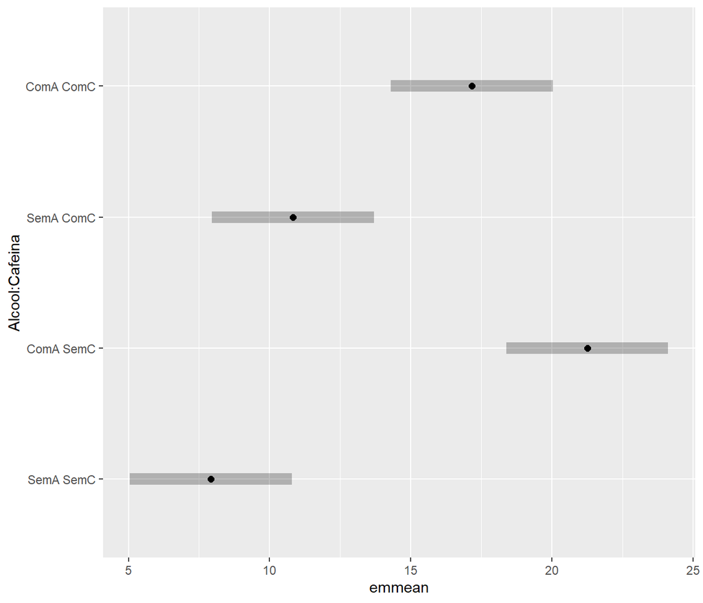

```r
print(plot(EMM.AC$emmeans,
           colors="black"))
```

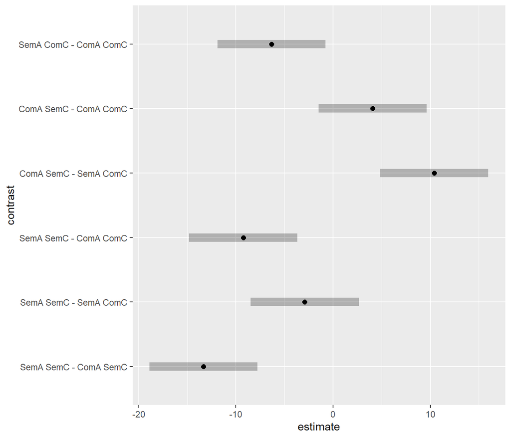

```r
print(plot(EMM.AC$contrasts,
           colors="black"))
```

```r
print(multcomp::cld(object=EMM.AC$emmeans,
                    level=1-alfa,
                    adjust="holm",
                    Letters=letters,
                    alpha=alfa))
```

```
 Alcool Cafeina emmean   SE df lower.CL upper.CL .group
 SemA   SemC      7.92 1.42 44     4.21     11.6  a
 SemA   ComC     10.83 1.42 44     7.12     14.5  a
 ComA   ComC     17.17 1.42 44    13.46     20.9   b
 ComA   SemC     21.25 1.42 44    17.54     25.0   b

Degrees-of-freedom method: satterthwaite
Confidence level used: 0.95
Conf-level adjustment: bonferroni method for 4 estimates
P value adjustment: holm method for 6 tests
significance level used: alpha = 0.05
NOTE: If two or more means share the same grouping symbol,
      then we cannot show them to be different.
      But we also did not show them to be the same.
```

```r
cat("\n\tAlcool")
```

```
    Alcool
```

```r
EMM.A <- emmeans::emmeans(modelo,
                          specs=pairwise~"Alcool",
                          adjust="holm",
                          level=1-alfa,
                          lmer.df="satterthwaite",
                          lmerTest.limit=nrow(Dados))
```

```
NOTE: Results may be misleading due to involvement in interactions
```

```r
print(summary(EMM.A$emmeans))
```

```
 Alcool emmean   SE df lower.CL upper.CL
 SemA     9.38 1.01 44     7.35     11.4
 ComA    19.21 1.01 44    17.18     21.2

Results are averaged over the levels of: Cafeina
Degrees-of-freedom method: satterthwaite
Confidence level used: 0.95
```

```r
print(summary(EMM.A$contrasts, infer=TRUE))
```

```
 contrast    estimate   SE df lower.CL upper.CL t.ratio p.value
 SemA - ComA    -9.83 1.42 44    -12.7    -6.96  -6.906  <.0001

Results are averaged over the levels of: Cafeina
Degrees-of-freedom method: satterthwaite
Confidence level used: 0.95
```

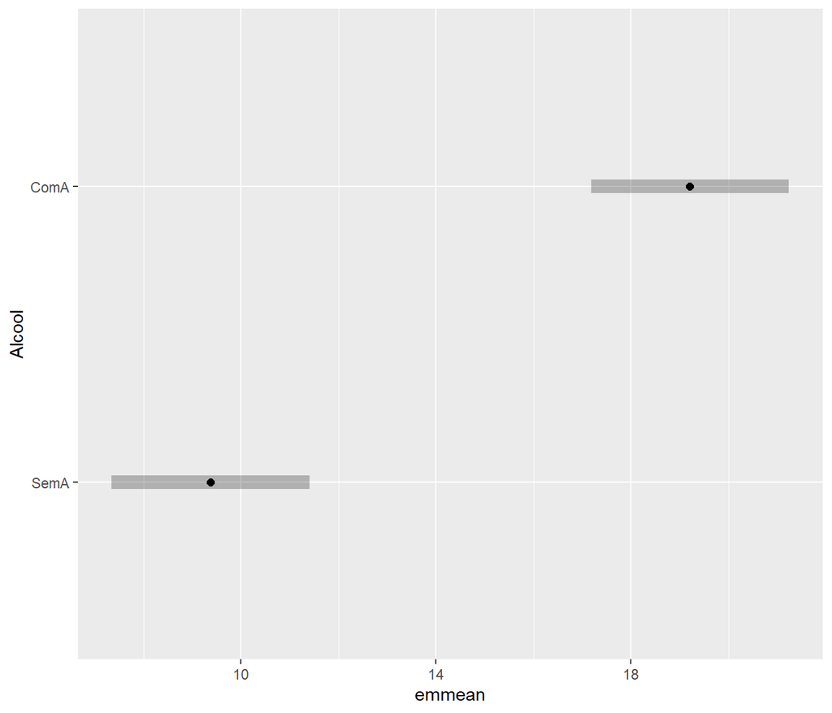

```r
print(plot(EMM.A$emmeans,
           colors="black"))
```

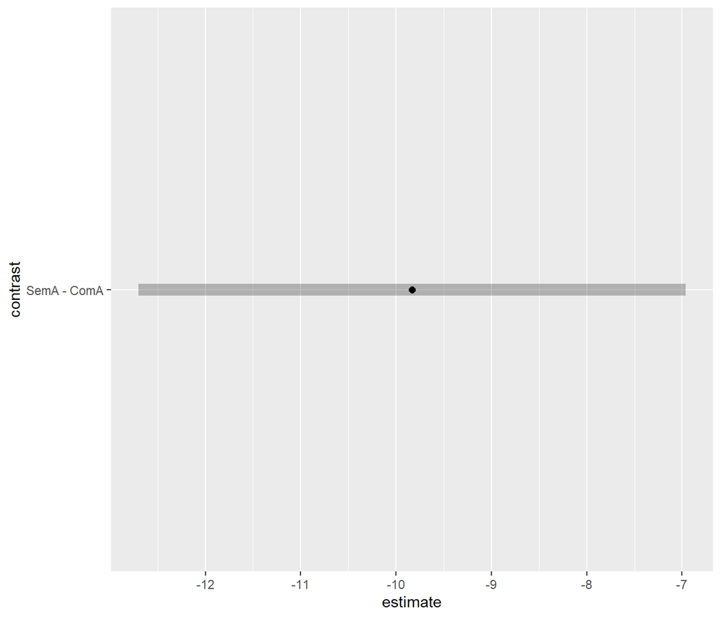

```r
print(plot(EMM.A$contrasts,
           colors="black"))
```

```r
print(multcomp::cld(object=EMM.A$emmeans,
                    level=1-alfa,
                    adjust="holm",
                    Letters=letters,
                    alpha=alfa))
```

```
 Alcool emmean   SE df lower.CL upper.CL .group
 SemA     9.38 1.01 44     7.04     11.7  a
 ComA    19.21 1.01 44    16.87     21.5   b

Results are averaged over the levels of: Cafeina
Degrees-of-freedom method: satterthwaite
Confidence level used: 0.95
Conf-level adjustment: bonferroni method for 2 estimates
significance level used: alpha = 0.05
NOTE: If two or more means share the same grouping symbol,
      then we cannot show them to be different.
      But we also did not show them to be the same.
```

```r
cat("\n\tCafeina")
```

```
    Cafeina
```

```r
EMM.C <- emmeans::emmeans(modelo,
                          specs=pairwise~"Cafeina",
                          adjust="holm",
                          level=1-alfa,
                          lmer.df="satterthwaite",
                          lmerTest.limit=nrow(Dados))
```

```
NOTE: Results may be misleading due to involvement in interactions
```

```r
print(summary(EMM.C$emmeans))
```

```
 Cafeina emmean   SE df lower.CL upper.CL
 SemC      14.6 1.01 44     12.6     16.6
 ComC      14.0 1.01 44     12.0     16.0

Results are averaged over the levels of: Alcool
Degrees-of-freedom method: satterthwaite
Confidence level used: 0.95
```

```r
print(summary(EMM.C$contrasts, infer=TRUE))
```

```
 contrast    estimate   SE df lower.CL upper.CL t.ratio p.value
 SemC - ComC    0.583 1.42 44    -2.29     3.45   0.410  0.6840

Results are averaged over the levels of: Alcool
Degrees-of-freedom method: satterthwaite
Confidence level used: 0.95
```

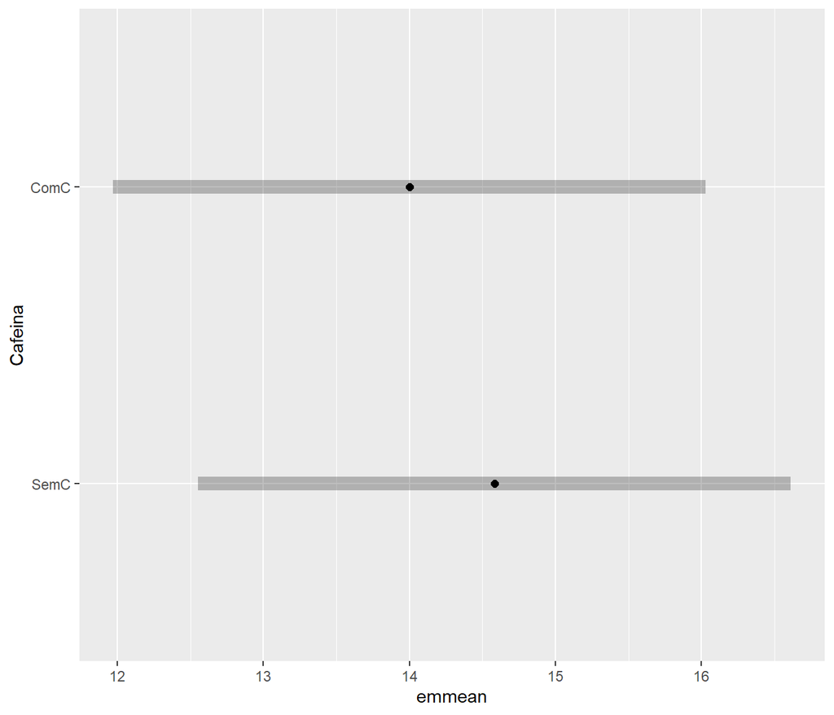

```r
print(plot(EMM.C$emmeans,
           colors="black"))
```

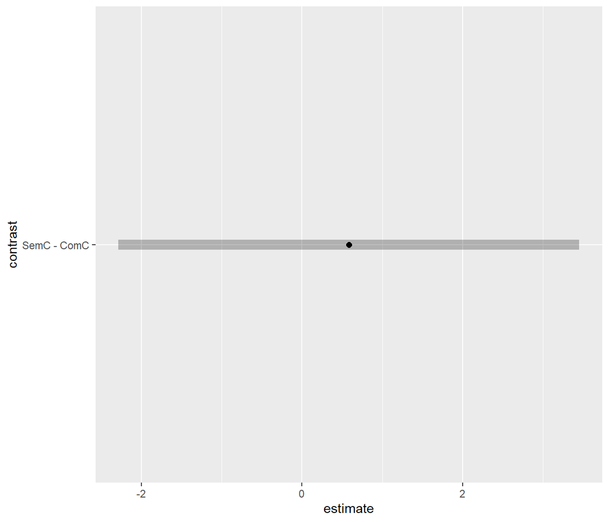

```r
print(plot(EMM.C$contrasts,
           colors="black"))
```

```r
print(multcomp::cld(object=EMM.C$emmeans,
                    level=1-alfa,
                    adjust="holm",
                    Letters=letters,
                    alpha=alfa))
```

```
 Cafeina emmean   SE df lower.CL upper.CL .group
 ComC      14.0 1.01 44     11.7     16.3  a
 SemC      14.6 1.01 44     12.2     16.9  a

Results are averaged over the levels of: Alcool
Degrees-of-freedom method: satterthwaite
Confidence level used: 0.95
Conf-level adjustment: bonferroni method for 2 estimates
significance level used: alpha = 0.05
NOTE: If two or more means share the same grouping symbol,
      then we cannot show them to be different.
      But we also did not show them to be the same.
```

# ANOVA bifatorial mista

Na ANOVA bifatorial mista, a identificação de cada um dos participantes (UE) aparece duas vezes, de tal forma que há apenas 24 participantes no total, alocados nos quatro tratamentos da seguinte maneira:

- 12 participantes sem Álcool, submetidos às duas condições:
  - com Cafeína,
  - sem Cafeína
- 12 participantes com Álcool, submetidos às duas condições:
  - com Cafeína,
  - sem Cafeína.

Por isso, o Álcool é o fator entre participantes, mas a Cafeína é intra participantes.

Os dados estão em `Cafeinaintra_Alcoolentre.rds`.

```r
Dados <- data.frame(readxl::read_excel("Cafeinaintra_Alcoolentre.xlsx"))
Dados$UE <- factor(Dados$UE)
Dados$Cafeina <- factor(Dados$Cafeina,
                        levels=c("SemC","ComC"))
Dados$Alcool <- factor(Dados$Alcool,
                       levels=c("SemA","ComA"))
saveRDS(Dados, "Cafeinaintra_Alcoolentre.rds")
```

```r
Dados <- readRDS("Cafeinaintra_Alcoolentre.rds")
str(Dados)
```

```
'data.frame':   48 obs. of  4 variables:
 $ UE      : Factor w/ 24 levels "1","2","3","4",..: 1 1 2 2 3 3 4 4 5 5 ...
 $ NumErros: num  4 15 9 8 10 17 8 0 6 15 ...
 $ Alcool  : Factor w/ 2 levels "SemA","ComA": 1 1 1 1 1 1 1 1 1 1 ...
 $ Cafeina : Factor w/ 2 levels "SemC","ComC": 1 2 1 2 1 2 1 2 1 2 ...
```

```r
print.data.frame(Dados)
```

```
   UE NumErros Alcool Cafeina
1   1        4   SemA    SemC
2   1       15   SemA    ComC
3   2        9   SemA    SemC
4   2        8   SemA    ComC
5   3       10   SemA    SemC
6   3       17   SemA    ComC
7   4        8   SemA    SemC
8   4        0   SemA    ComC
9   5        6   SemA    SemC
10  5       15   SemA    ComC
11  6       11   SemA    SemC
12  6       11   SemA    ComC
13  7        2   SemA    SemC
14  7       11   SemA    ComC
```

[output cut: 34 more lines]

```r
print(summary(Dados))
```

```
       UE        NumErros      Alcool   Cafeina
 1      : 2   Min.   : 0.00   SemA:24   SemC:24
 2      : 2   1st Qu.:10.00   ComA:24   ComC:24
 3      : 2   Median :15.00
 4      : 2   Mean   :14.29
 5      : 2   3rd Qu.:19.25
 6      : 2   Max.   :28.00
 (Other):36
```

```r
print(ftable(Dados[,-2]))
```

```
          Cafeina SemC ComC
UE Alcool
1  SemA              1    1
   ComA              0    0
2  SemA              1    1
   ComA              0    0
3  SemA              1    1
   ComA              0    0
4  SemA              1    1
   ComA              0    0
5  SemA              1    1
   ComA              0    0
6  SemA              1    1
   ComA              0    0
7  SemA              1    1
   ComA              0    0
8  SemA              1    1
   ComA              0    0
9  SemA              1    1
   ComA              0    0
10 SemA              1    1
   ComA              0    0
11 SemA              1    1
   ComA              0    0
12 SemA              1    1
   ComA              0    0
13 SemA              0    0
   ComA              1    1
14 SemA              0    0
   ComA              1    1
15 SemA              0    0
   ComA              1    1
16 SemA              0    0
   ComA              1    1
17 SemA              0    0
   ComA              1    1
18 SemA              0    0
   ComA              1    1
19 SemA              0    0
   ComA              1    1
20 SemA              0    0
   ComA              1    1
21 SemA              0    0
   ComA              1    1
22 SemA              0    0
   ComA              1    1
23 SemA              0    0
   ComA              1    1
24 SemA              0    0
   ComA              1    1
```

```r
source("summarySEwithin2.R")
Dados <- readRDS("Cafeinaintra_Alcoolentre.rds")
alfa <- 0.05
print(ftable(Dados[,-2]))
```

```
          Cafeina SemC ComC
UE Alcool
1  SemA              1    1
   ComA              0    0
2  SemA              1    1
   ComA              0    0
3  SemA              1    1
   ComA              0    0
4  SemA              1    1
   ComA              0    0
5  SemA              1    1
   ComA              0    0
6  SemA              1    1
   ComA              0    0
7  SemA              1    1
   ComA              0    0
8  SemA              1    1
   ComA              0    0
9  SemA              1    1
   ComA              0    0
10 SemA              1    1
   ComA              0    0
11 SemA              1    1
   ComA              0    0
12 SemA              1    1
   ComA              0    0
13 SemA              0    0
   ComA              1    1
14 SemA              0    0
   ComA              1    1
15 SemA              0    0
   ComA              1    1
16 SemA              0    0
   ComA              1    1
17 SemA              0    0
   ComA              1    1
18 SemA              0    0
   ComA              1    1
19 SemA              0    0
   ComA              1    1
20 SemA              0    0
   ComA              1    1
21 SemA              0    0
   ComA              1    1
22 SemA              0    0
   ComA              1    1
23 SemA              0    0
   ComA              1    1
24 SemA              0    0
   ComA              1    1
```

```r
print(psych::describe(NumErros ~ Alcool*Cafeina,
                      data=Dados), digits=2)
```

```
 Descriptive statistics by group
Alcool: SemA
Cafeina: SemC
         vars  n mean   sd median trimmed  mad min max range  skew kurtosis
NumErros    1 12 7.92 3.32    9.5     8.2 2.22   2  11     9 -0.63    -1.35
           se
NumErros 0.96
------------------------------------------------------------
Alcool: ComA
Cafeina: SemC
         vars  n  mean   sd median trimmed  mad min max range skew kurtosis
NumErros    1 12 21.25 3.72   20.5    21.1 2.22  16  28    12 0.49    -1.04
           se
NumErros 1.07
------------------------------------------------------------
Alcool: SemA
Cafeina: ComC
         vars  n  mean   sd median trimmed  mad min max range skew kurtosis
NumErros    1 12 10.83 6.12     13    11.3 4.45   0  17    17 -0.7    -1.08
           se
NumErros 1.77
------------------------------------------------------------
Alcool: ComA
Cafeina: ComC
         vars  n  mean   sd median trimmed  mad min max range skew kurtosis
NumErros    1 12 17.17 5.92     15    16.9 6.67  10  27    17 0.41    -1.24
           se
NumErros 1.71
```

```r
alfaBonf <- alfa/(length(unique(Dados$Alcool))*
                  length(unique(Dados$Cafeina)))
ic <- summarySEwithin2(Dados,
                       measurevar="NumErros",
                       withinvars=c("Alcool","Cafeina"),
                       idvar="UE",
                       na.rm=TRUE,
                       conf.interval=1-alfaBonf)
print(ic)
```

```
  Alcool Cafeina  N  NumErros NumErrosNormed       sd       se       ci
1   ComA    ComC 12 17.166667       12.25000 4.468464 1.289934 3.845130
2   ComA    SemC 12 21.250000       16.33333 4.468464 1.289934 3.845130
3   SemA    ComC 12 10.833333       15.75000 4.562418 1.317057 3.925978
4   SemA    SemC 12  7.916667       12.83333 4.562418 1.317057 3.925978
```

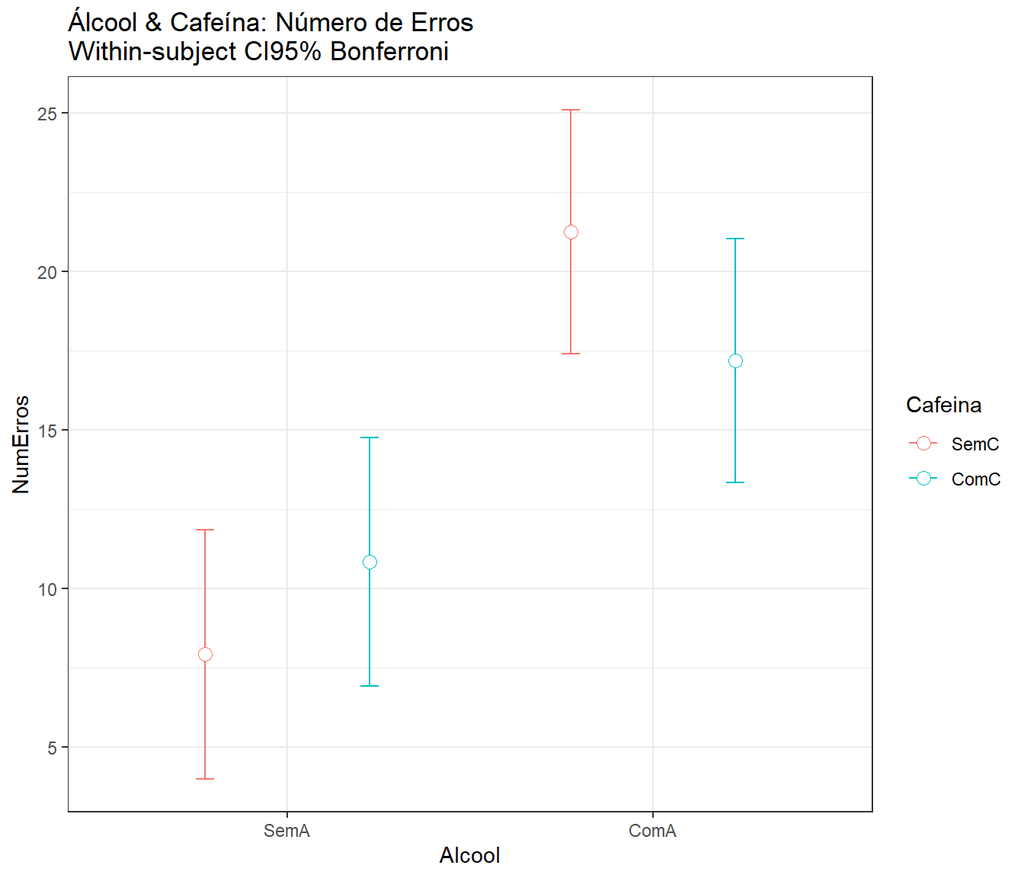

```r
grf <- ggplot2::ggplot(ic,
                       ggplot2::aes(x=Alcool,
                                    y=NumErros,
                                    colour=Cafeina)) +
  ggplot2::geom_errorbar(position=ggplot2::position_dodge(.9),
                         width=.1,
                         ggplot2::aes(ymin=NumErros-ci,
                                      ymax=NumErros+ci)) +
  ggplot2::geom_point(shape=21,
                      size=3,
                      fill="white",
                      position=ggplot2::position_dodge(.9)) +
  ggplot2::ylab("NumErros") +
  ggplot2::ggtitle("Álcool & Cafeína: Número de Erros\nWithin-subject CI95% Bonferroni") +
  ggplot2::theme_bw()
print(grf)
```